# Seminarski rad iz predmeta Uvod u nauku o podacima

2025-11-22

# Analiza skupa podataka: Global Mobile Review Dataset

## Opis problema

Skup podataka *Global Mobile Review* sadrži podatke o mobilnim uređajima i ocenama korisnika za svaki pojedinačni model. Ovaj skup podataka preuzet je sa sajta *kaggle.com*.

Glavni cilj analize jeste da predvidi krajnju ocenu korisnika, vrednost od 1 do 5, na osnovu prisutnih podataka.

Programski jezik koji ce se koristiti za dalju analizu je R.

## Učitavanje biblioteka za obradu podataka

Kako bismo počeli sa analizom skupa podataka, potrebno je najpre učitati biblioteke sa kojima ćemo dalje raditi.

```r
library(tidyverse)
library(randomForest)
```

```r
library(corrplot)
library(class)
library(caret)
library(nnet)
library(e1071)
library(kknn)
library(rpart)
library(xgboost)
library(pROC)
```

## Učitavanje skupa podataka

Prvi korak u analizi jeste da učitamo skup podataka.

Skup podataka se nalazi u CSV formatu, a sam naziv fajla je *Mobile_Reviews_Sentiment.csv*.

```r
reviews = read.csv("Mobile_Reviews_Sentiment.csv", stringsAsFactors = FALSE)
```

Nakon učitavanja, pogledaćemo sa kojom količinom podataka raspolažemo kako bismo u daljem radu mogli adekvatno da planiramo podelu skupa podataka na trening i test skup.

Skup podataka sastoji se od 50 000 redova, odnosno u našem slučaju pojedinačnih ocena za uređaje, kao i 25 kolona od kojih je jedna ciljna promenljiva.

```r
dim(reviews)
```

```
## [1] 50000    25
```

Sada, kada je skup podataka učitan, možemo pogledati strukturu njegovih podataka, odnosno kolona.

Možemo primetiti da je struktura podataka uglavnom kategorijska. Iako vidimo podjednak broj numeričkih vrednosti, kao što su *camera_rating*, *performance_rating* i slično, te promenljive verovatno imaju vrednost od 1 – 5 i u daljem radu će biti posmatrane kao kategorijske ukoliko nam ne bude drugačije bilo potrebno za obradu.

Prave numeričke vrednosti se mogu primetiti kod promenljivih *price_usd*, *exchange_rate_to_usd*, kao i trenutno kategorijska promenljiva *price_local*. Ova promenljiva je trenutno kategorijskog tipa zbog specijalnih karaktera koje možemo primetiti na početku i na kraju koji predstavljaju oznaku domaće valute i to će najverovatnije u budućem radu biti uklonjeno radi lakse obrade podataka

```r
str(reviews)
```

```
## 'data.frame':    50000 obs. of  25 variables:
##  $ review_id           : int  1 2 3 4 5 6 7 8 9 10 ...
##  $ customer_name       : chr  "Aryan Maharaj" "Davi Miguel Sousa" "Pahal Balay" "David Guzman" ...
##  $ age                 : int  45 18 27 19 38 38 40 39 32 31 ...
##  $ brand               : chr  "Realme" "Realme" "Google" "Xiaomi" ...
##  $ model               : chr  "Realme 12 Pro" "Realme 12 Pro" "Pixel 6" "Redmi Note 13" ...
##  $ price_usd           : num  337 308 865 661 792 ...
##  $ price_local         : chr  "₹27996.73" "R$1754.35" "₹71755.99" "د.إ2425.65" ...
##  $ currency            : chr  "INR" "BRL" "INR" "AED" ...
##  $ exchange_rate_to_usd: num  83 5.7 83 3.67 5.7 5.7 3.67 1.53 0.93 1.53 ...
##  $ rating              : int  2 4 4 3 3 5 3 2 4 3 ...
##  $ review_text         : chr  "Not worth the money spent. Wouldn’t recommend." "Absolutely love this phone! The camera is next level. Absolutely worth it!" "Loving the clean UI and fast updates. Loving it so far!" "Build quality feels solid and durable. No regrets buying this one." ...
##  $ sentiment           : chr  "Negative" "Positive" "Positive" "Positive" ...
##  $ country             : chr  "India" "Brazil" "India" "UAE" ...
##  $ language            : chr  "Hindi" "Portuguese" "Hindi" "English" ...
##  $ review_date         : chr  "2023-11-06" "2023-03-30" "2022-12-07" "2025-03-11" ...
##  $ verified_purchase   : chr  "True" "True" "True" "False" ...
##  $ battery_life_rating : int  1 3 3 1 3 5 3 2 4 2 ...
##  $ camera_rating       : int  1 2 5 3 3 4 3 1 3 2 ...
##  $ performance_rating  : int  3 4 3 2 2 5 2 2 2 3 ...
##  $ design_rating       : int  2 3 2 1 2 5 1 2 3 3 ...
##  $ display_rating      : int  1 2 4 2 1 4 2 2 3 2 ...
##  $ review_length       : int  46 74 55 66 73 70 58 56 60 72 ...
##  $ word_count          : int  7 12 11 11 12 13 10 8 12 12 ...
##  $ helpful_votes       : int  1 5 8 3 0 6 2 3 8 4 ...
##  $ source              : chr  "Amazon" "Flipkart" "AliExpress" "Amazon" ...
```

Dodatno, možemo pogledati i detaljniju strukturu podataka: da li ima nedostajućih vrednosti, koji je maksimum/minimum numeričkih vrednosti i slično.

Ono što možemo primetiti je da nema nedostajućih vrednosti na prvi pogled, mada će za kategorijske promenljive biti potrebna dodatna provera. Prazan string se ovde neće smatrati nedostajućom vrednošću, ali logički on to jeste.

Svaka promenljiva će biti pojedinacno objasnjena u nastavku.

```r
summary(reviews)
```

```
##    review_id     customer_name           age           brand
##  Min.   :    1   Length:50000       Min.   :18.00   Length:50000
##  1st Qu.:12501   Class :character   1st Qu.:23.00   Class :character
##  Median :25000   Mode  :character   Median :29.00   Mode  :character
##  Mean   :25000                      Mean   :30.08
##  3rd Qu.:37500                      3rd Qu.:36.00
##  Max.   :50000                      Max.   :65.00
##     model             price_usd      price_local          currency
##  Length:50000       Min.   : 180.0   Length:50000       Length:50000
##  Class :character   1st Qu.: 450.8   Class :character   Class :character
##  Mode  :character   Median : 637.0   Mode  :character   Mode  :character
##                     Mean   : 689.7
##                     3rd Qu.: 901.0
##                     Max.   :1499.9
##  exchange_rate_to_usd     rating      review_text         sentiment
##  Min.   : 0.78        Min.   :1.000   Length:50000       Length:50000
##  1st Qu.: 1.00        1st Qu.:2.000   Class :character   Class :character
##  Median : 1.53        Median :3.000   Mode  :character   Mode  :character
##  Mean   :12.06        Mean   :3.123
##  3rd Qu.: 5.70        3rd Qu.:4.000
##  Max.   :83.00        Max.   :5.000
##    country            language         review_date        verified_purchase
##  Length:50000       Length:50000       Length:50000       Length:50000
##  Class :character   Class :character   Class :character   Class :character
##  Mode  :character   Mode  :character   Mode  :character   Mode  :character
##
##
##
##  battery_life_rating camera_rating   performance_rating design_rating
##  Min.   :1.000       Min.   :1.000   Min.   :1.00       Min.   :1.000
##  1st Qu.:1.000       1st Qu.:1.000   1st Qu.:1.00       1st Qu.:1.000
##  Median :3.000       Median :3.000   Median :3.00       Median :3.000
##  Mean   :2.718       Mean   :2.718   Mean   :2.72       Mean   :2.714
##  3rd Qu.:4.000       3rd Qu.:4.000   3rd Qu.:4.00       3rd Qu.:4.000
##  Max.   :5.000       Max.   :5.000   Max.   :5.00       Max.   :5.000
##  display_rating  review_length     word_count    helpful_votes
##  Min.   :1.000   Min.   :45.00   Min.   : 6.00   Min.   : 0.000
##  1st Qu.:1.000   1st Qu.:56.00   1st Qu.: 9.00   1st Qu.: 2.000
##  Median :3.000   Median :63.00   Median :11.00   Median : 3.000
##  Mean   :2.721   Mean   :62.79   Mean   :10.62   Mean   : 3.644
##  3rd Qu.:4.000   3rd Qu.:68.00   3rd Qu.:12.00   3rd Qu.: 5.000
##  Max.   :5.000   Max.   :82.00   Max.   :15.00   Max.   :17.000
##     source
##  Length:50000
##  Class :character
##  Mode  :character
##
##
##
```

## Opis i analiza pojedinačnih promenljivih

Kako bismo stekli uvid u strukturu, raspodelu i značenje svake promenljive, detaljno ćemo proći kroz skup podataka i analizirati svaku pojedinačno uz pojašnjenje šta svaka od njih predstavlja, odnosno opisuje. Na ovaj način ćemo videti i da li promenljive imaju nedostajuće vrednosti i odlučiti šta da uradimo sa njima ukoliko postoje.

### review_id

Ova promenljiva predstavlja jedinstveni identifikator svakog reda u skupu podataka, odnosno jedinstveni identifikator svake pojedinačne ocene.

Možemo videti da se identifikatori kreću u intervalu od 1 do 50 000 (uključujući ove vrednosti) što odgovara ukupnoj količini podataka koju imamo.

```r
summary(reviews$review_id)
```

```
##    Min. 1st Qu.  Median    Mean 3rd Qu.    Max.
##       1   12501   25000   25000   37500   50000
```

### customer_name

Ime osobe koja ostavlja ocenu.

Iako logički možemo pretpostaviti da ova promenljiva nema velikog znacaja na konačnu ocenu samog proizvoda, možemo proveriti da li ima nedostajućih vrednosti. Posto je ovo kategorijska promenljiva tipa String, proverićemo da li prazan String kao svoju vrednost.

Na osnovu rezultata komande ispod možemo videti da ova kolona nema “skrivene” nedostajuće vrednosti

```r
sum(reviews[reviews$customer_name == ""])
```

```
## [1] 0
```

### age

Godine su numerička vrednost koja predstavlja koliko osoba koja je ostavila ocenu ima godina.

Minimum godina koje osoba ima u našem skupu podataka je 18 - što znači da su sve ispitane osobe punoletne, dok je maksimalan broj godina 65.

```r
summary(reviews$age)
```

```
##    Min. 1st Qu.  Median    Mean 3rd Qu.    Max.
##   18.00   23.00   29.00   30.08   36.00   65.00
```

Na osnovu grafika ispod - koji označava raspodelu vrednosti same promenljive, možemo videti da su najveći broj ocena ostavili mladi od 18 - 22 godine, zatim osobe srednjih godina i najmanje starije osobe - iznad 50 godina. možemo reći da je ovo i očekivano, uzimajući u obzir da mlađe generacije mnogo više koriste mobilne uređaje.

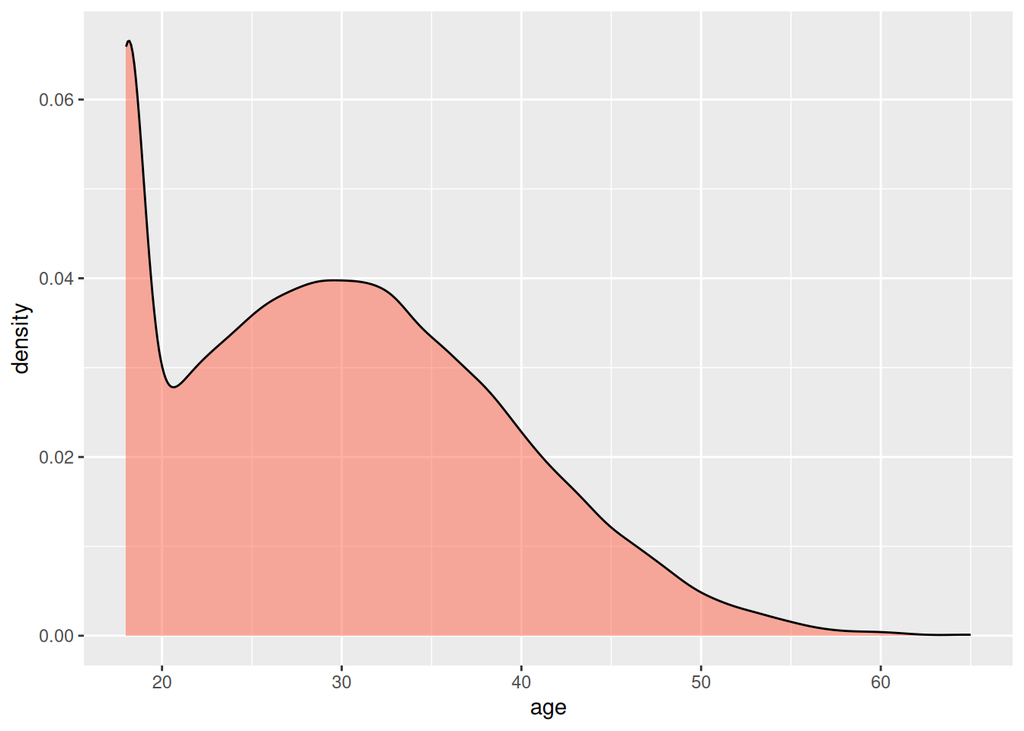

```r
ggplot(reviews, aes(x = age)) +
  geom_density(fill = "tomato", alpha = 0.5)
```

### brand

Promenljiva koja označava brend, odnosno proizvođaca samog uređaja (na primer Apple, Sumsung…).

Ovaj skup podataka razlikuje 7 proizvođača mobilnih uređaja kao sto se može videti u tabeli ispod.

Dodatno, na osnovu vrednosti koja predstavlja broj pojavljivanja proizvođača, možemo potvrditi da je učestalost gotovo podjednaka.

```r
table(reviews$brand)
```

```
##
##    Apple   Google Motorola  OnePlus   Realme  Samsung   Xiaomi
##     7144     7234     7061     7136     7132     7052     7241
```

Vizuelni prikaz će još adekvatnije prikazati podjednaku zastupljenost svih 7 proizvođača u našem skupu podataka.

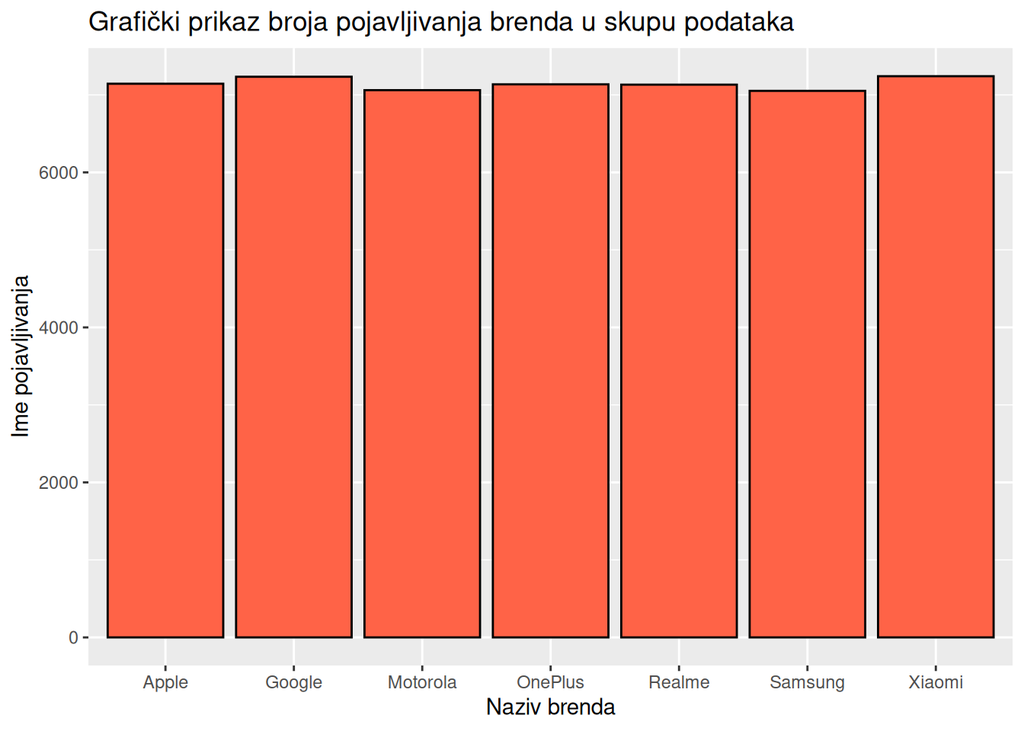

```r
ggplot(reviews, aes(x = brand)) +
  geom_bar(fill = "tomato", color = "black") +
  labs(title = "Grafički prikaz broja pojavljivanja brenda u skupu podataka",
       x = "Naziv brenda",
       y = "Ime pojavljivanja")
```

Po svojoj prirodi, ovo je kategorijska promenljiva i ima ograničen broj kategorija, tako da ćemo je pretvoriti u faktorsku (kategorijsku) promenlju radi dalje obrade.

```r
reviews$brand = factor(reviews$brand)
```

### model

Usko povezan sa prethodnom promenljivom, model, kao što i samo ime kaže, predstavlja model samog uređaja.

U tabeli ispod možemo videti koji modeli su kupovani i ocenjivani u našem skupu podataka.

Pošto ima relativno veliki broj kategorija, najbolje je njihovu zastupljenost predstaviti korišćenjem grafika.

```r
table(reviews$model)
```

```
##
##         Edge 50      Galaxy A55  Galaxy Note 20      Galaxy S24   Galaxy Z Flip
##            2315            1788            1789            1761            1714
##       iPhone 13       iPhone 14   iPhone 15 Pro       iPhone SE       Mi 13 Pro
##            1767            1788            1793            1796            2445
##    Moto G Power     OnePlus 11R      OnePlus 12  OnePlus Nord 3         Pixel 6
##            2351            2433            2323            2380            2379
##        Pixel 7a         Pixel 8         Poco X6         Razr 40   Realme 12 Pro
##            2468            2387            2326            2395            3535
## Realme Narzo 70   Redmi Note 13
##            3597            2470
```

Na grafičkom prikazu je mnogo lakše uočiti isticanje dva modela u broju pojavljivanja, a to su: Realme 12 Pro i Realme Narzo 70

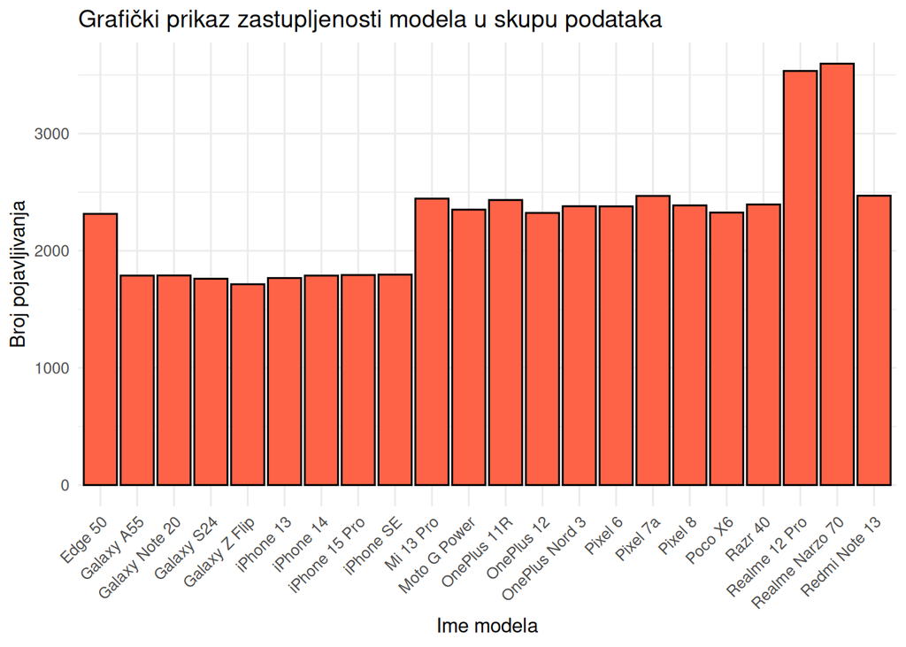

```r
ggplot(reviews, aes(x = model)) +
  geom_bar(fill = "tomato", color = "black") +
  theme_minimal() +
  theme(axis.text.x = element_text(angle = 45, hjust = 1)) +
  labs(title = "Grafički prikaz zastupljenosti modela u skupu podataka",
       x = "Ime modela",
       y = "Broj pojavljivanja")
```

Kao što smo imali situaciju sa brendom, i ova promenljiva je po svojoj prirodi kategorijska, tako da ćemo je u nju i pretvoriti.

```r
reviews$model = factor(reviews$model)
```

### price_usd

Cena pojedinačnog uređaja u američkim dolarima.

Ova promenljiva je kontinualna numerička vrednost iz intervala [180, 1500).

```r
summary(reviews$price_usd)
```

```
##    Min. 1st Qu.  Median    Mean 3rd Qu.    Max.
##   180.0   450.8   637.0   689.7   901.0  1499.9
```

Predstavimo raspodelu cena grafikom. Na grafiku primećujemo da najviše ima cena u raponu od 500 - 700 USD, što je negde prosečna cena telefona.

```
## Ignoring unknown labels:
## • Y : "Učestalost"
```

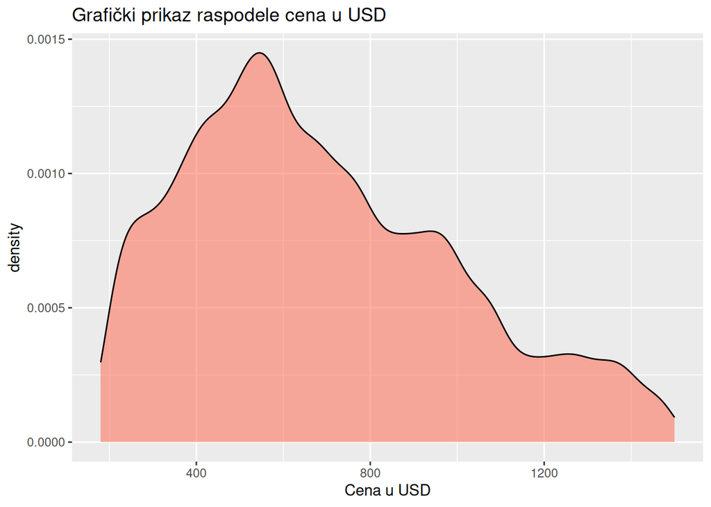

```r
ggplot(reviews, aes(x = price_usd)) +
  geom_density(fill = "tomato", alpha = 0.5) +
  labs(title = "Grafički prikaz raspodele cena u USD",
       x = "Cena u USD",
       Y = "Učestalost")
```

### price_local

Cena pojedinačnog uređaja izražena u lokalnoj valuti.

Možemo primetiti da je ova promenljiva, iako je logično da bude numerička, predstavljena kao kategorijska. Pogledajmo kako izgledaju vrednosti unutar ove kolone.

```r
summary(reviews$price_local)
```

```
##    Length     Class      Mode
##     50000 character character
```

Razlog što je ova promenljiva označena kao kategorijska su specijalni karakteri koji predstavljaju oznaku lokalne valute.

Ovi specijalni karakteri nalaze se i na pocetku i na kraju vrednosti.

```r
head(reviews$price_local)
```

```
## [1] "₹27996.73"  "R$1754.35"  "₹71755.99"  "د.إ2425.65" "R$4515.14"
## [6] "R$5408.1"
```

Kako bismo mogli da obrađujemo ovu kolonu adekvatno u daljem radu, potrebno je da uklonimo specijalne karaktere i pretvorimo je u numeričku.

Najpre ćemo kreirati funkcije koje ce ukloniti specijalne karaktere koji se nalaze na pocetku i/ili kraju vrednosti.

```r
remove_from_start <- function(x) {
  gsub("^[^0-9]*", "", x)
}

remove_from_end <- function(x) {
  gsub("[^0-9]*$", "", x)
}
```

Sada ćemo kreirane funkcije za uklanjanje specijalnih karaktera sa početka i kraja vrednosti da primenimo nad celom kolonom.

```r
reviews$price_local = remove_from_start(reviews$price_local)
reviews$price_local = remove_from_end(reviews$price_local)
```

Možemo videti da sada nemamo specijalne karaktere na početku ili kraju, već da su ostale samo brojčane vrednosti.

```r
head(reviews$price_local)
```

```
## [1] "27996.73" "1754.35"  "71755.99" "2425.65"  "4515.14"  "5408.1"
```

Sada je trenutak da te vrednosti pretvorimo u numeričke.

```r
reviews$price_local = as.numeric(reviews$price_local)
```

### currency

Valuta u kojoj je izražen iznos u price_local.

Ovo je kategorijska promenljiva koja nam ne govori samo o valuti, nego i o zemlji iz koje pojedinac dolazi. Ovaj podatak možda bude imao značaja u budućnosti.

Preko tabele ćemo pogledati koje kategorije su zastupljene i da li postoje nedostajuće vrednosti u vidu praznog stringa.

možemo primetiti 8 valuta i 8 zemalja:

- AED -> Ujedinjeni Arapski Emirati Dirham
- AUD -> Australijski dolar
- BRL -> Brazilski real
- CAD -> Kanadski dolar
- EUR -> Euro
- GBP -> Britanska funta
- INR -> Indijska ruplja
- USD -> Američki dolar

```r
table(reviews$currency)
```

```
##
##  AED  AUD  BRL  CAD  EUR  GBP  INR  USD
## 6261 6219 6419 6170 6162 6210 6124 6435
```

Po brojevima iz tabele možemo zaključiti da se u skupu podataka nalazi podjednak broj ispitanika po zemljama koje koriste ovu valutu, ali hajde da to potvrdimo i grafičkim prikazom.

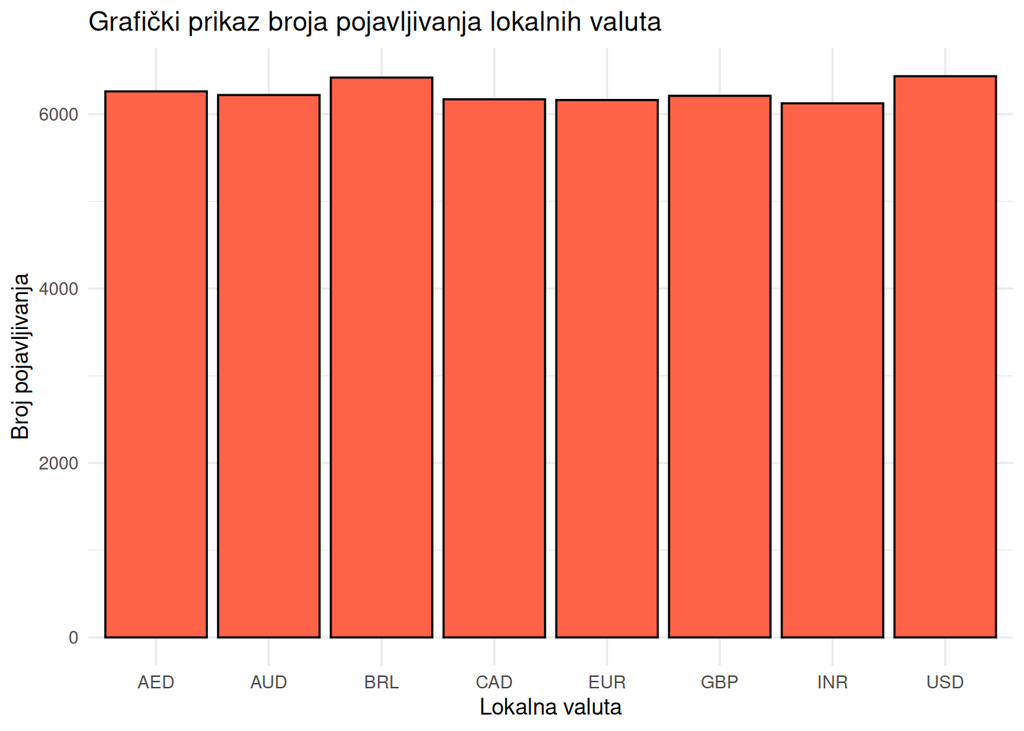

```r
ggplot(reviews, aes(x = currency)) +
  geom_bar(fill = "tomato", color = "black") +
  theme_minimal() +
  labs(title = "Grafički prikaz broja pojavljivanja lokalnih valuta",
       x = "Lokalna valuta",
       y = "Broj pojavljivanja")
```

Ova promenljiva je kategorijskog tipa, pa ćemo je stoga i pretvoriti u faktorsku promenljivu.

```r
reviews$currency = factor(reviews$currency)
```

### exchange_rate_to_usd

Ova promenljiva predstavlja kurs lokalne valute izražene u američkim dolarima - USD.

```r
summary(reviews$exchange_rate_to_usd)
```

```
##    Min. 1st Qu.  Median    Mean 3rd Qu.    Max.
##    0.78    1.00    1.53   12.06    5.70   83.00
```

Pošto je ovo kurs lokalne valute izražen u američkim dolarima, potrebno je da ima jedinstvenih vrednosti koliko i lokalnih valuta. U ovom slučaju to je 8.

Pomoću komande ispod možemo potvrditi da svaka valuta ima tačno jedan kurs što doprinosi konzistentnosti u skupu podataka

```r
length(unique(reviews$exchange_rate_to_usd))
```

```
## [1] 8
```

Dodatno, potrebno je proveriti koja vrednost odgovara kojoj valuti. Ovo je korisno da bi se uporedila tačnost.

Na primer, kurs za prebacivanje USD u USD treba biti 1 tj. da se vrednosti preslikavaju.

Hajde da to proverimo sledećom tablicom.

Odlično, možemo videti tablicu vrednosti i potvrditi da je tačna

```r
reviews %>%
  group_by(currency) %>%
  summarise(exchange_rate = unique(exchange_rate_to_usd))
```

| currency | exchange_rate |
| --- | --- |
| AED | 3.67 |
| AUD | 1.53 |
| BRL | 5.70 |
| CAD | 1.38 |
| EUR | 0.93 |
| GBP | 0.78 |
| INR | 83.00 |
| USD | 1.00 |

### rating

Ovo je kategorijska promenljiva koja označava stepen zadovoljstva odnosno samu ocenu uređaja. Ovo je ujedno i ciljna promenljiva u ovom skupu podataka.

Vrednosti unutar ove promenljive kreću se od 1 do 5, što znaci da je 1 minimalna ocena koju je moguće dodeliti, a 5 najviša ocena za pojedinačni uređaj.

```r
table(reviews$rating)
```

```
##
##     1     2     3     4     5
##  6377  9803 12449 14029  7342
```

Na osnovu grafika prikazanog ispod možemo zaključiti da najmanje ima uređaja kojima je osoba prezadovoljna ili u potpunosti nezadovoljna. Najviše osoba uređaj je ocenilo srednjim ocenama - 3 i 4.

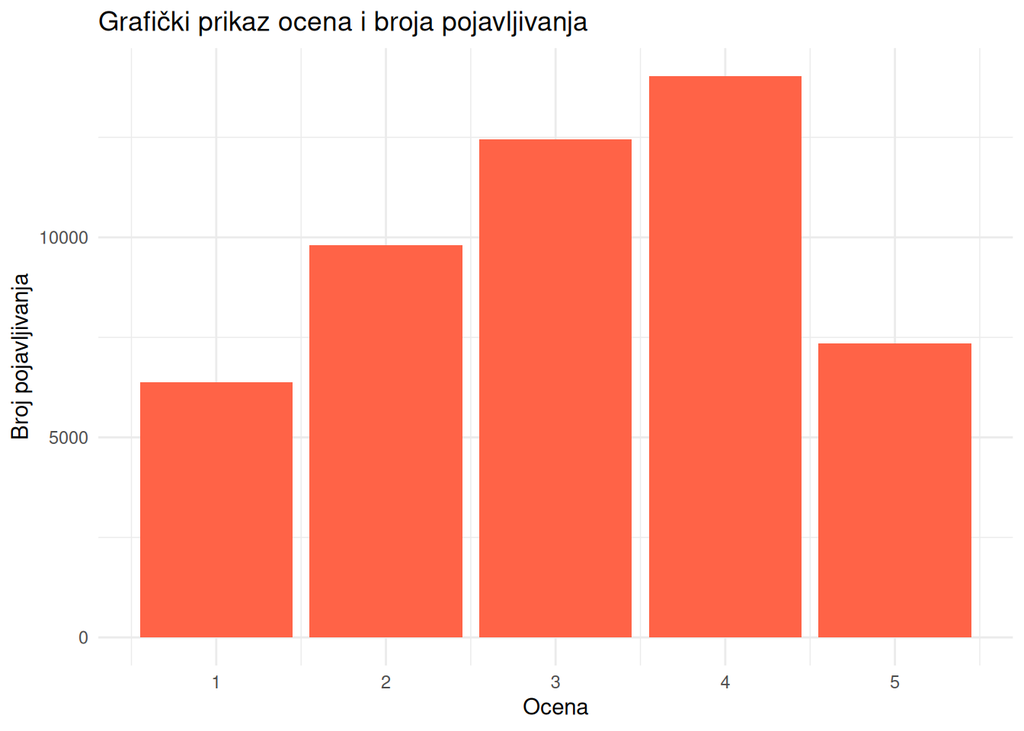

```r
ggplot(reviews, aes(x = rating)) +
  geom_bar(fill = "tomato", fill = "black") +
  theme_minimal() +
  labs(title = "Grafički prikaz ocena i broja pojavljivanja",
       x = "Ocena",
       y = "Broj pojavljivanja")
```

### review_text

Komentar za sam review o zadovoljstvu uređajem.

Ovo je String promenljiva, nije kategorijska

```r
summary(reviews$review_text)
```

```
##    Length     Class      Mode
##     50000 character character
```

### sentiment

Kategorijska promenljiva koja označava da li je u globalu osoba zadovoljna uređajem ili ne.

Ovo je kategorijska promenljiva sa tri vrednosti: - Negative (osoba nije zadovoljna uređajem) - Neutral (osoba je neutralna po pitanju izjašnjavanja o zadovoljstvu uređajem) - Positive (osoba je zadovoljna uređajem)

```r
table(reviews$sentiment)
```

```
##
## Negative  Neutral Positive
##     9911    12549    27540
```

možemo videti da je najveći broj korisnika zadovoljan izborom uređaja, što se slaže sa vrednostima promenljive rating gde je većina korisnika ocenila uređaj ocenama od 3 - 5.

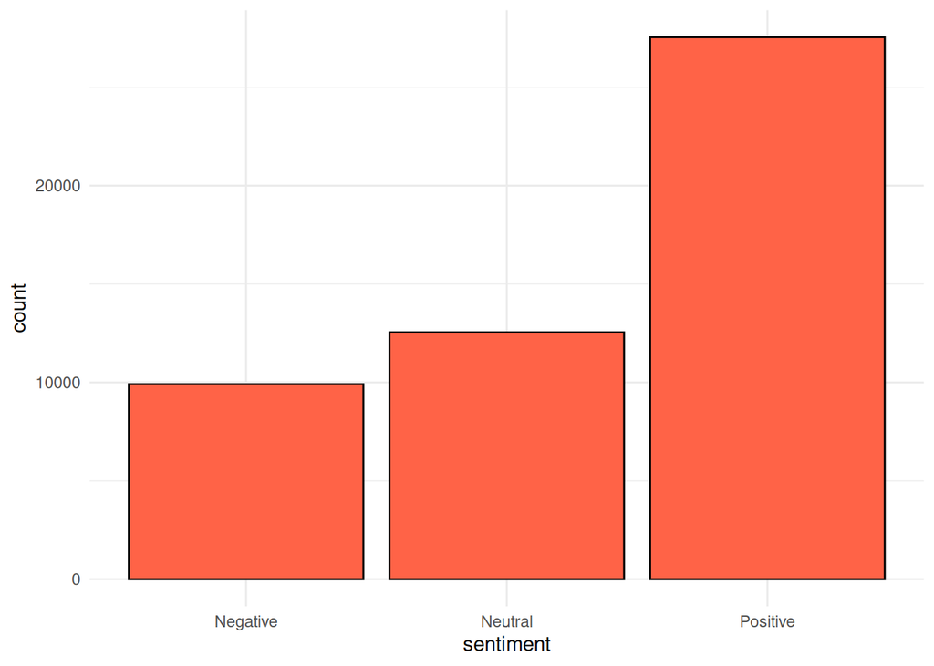

```r
ggplot(reviews, aes(x = sentiment)) +
  geom_bar(fill = "tomato", color = "black") +
  theme_minimal()
```

### country

Predstavlja zemlju iz koje dolazi osoba koja ocenjuje uređaj.

Iako se neke valute koriste u više drzava (na primer EUR) možemo videti da broj zemalja odgovara broju valuta.

možemo primetiti da je podjednak broj review-a iz ovih zemalja, sa neznatnim isticanjem Brazila i USA-a.

```r
table(reviews$country)
```

```
##
## Australia    Brazil    Canada   Germany     India       UAE        UK       USA
##      6219      6419      6170      6162      6124      6261      6210      6435
```

I ovu promenljivu ćemo pretvoriti u kategorijsku:

```r
reviews$country = factor(reviews$country)
```

### language

Ovo je još jedna promenljiva vezana za samog korisnika i predstavlja jezik kojim osoba govori.

Najveci broj ispitanika govori engleskim jezikom što je očekivano obzirom da imamo čak 4 zemlje (što je polovina u našem skupu podataka) gde je engleski jezik zvanični jezik: UK, USA, Autralija i deo Kanade.

```r
table(reviews$language)
```

```
##
##    English     German      Hindi Portuguese
##      31295       6162       6124       6419
```

Pretvorićemo ovu promenljivu u kategorijsku:

```r
reviews$language = factor(reviews$language)
```

### review_date

Datum ostavljanja review-a za uređaj.

### verified_purchace

Ova promenljiva nam može biti zanimljiva u budućnosti zato što predstavlja True/False tip promenljiva koja objašnjava da li je kupovina uređaja verifikovana ili ne.

možemo videti da je 1/5 ocena sa neverifikovanom ili nepotvrđenom kupovinom.

U nastavku ćemo posebnu pažnju posvetiti ovoj promenljivoj i razmotriti da li treba uzimati u obzir ocene koje nisu verifikovane. Da li neverifikovane kupovine treba smatrati za outlier-e ukoliko ocena odskače od ostatka za taj uređaj?

Ovo su sve pitanja na koja je potrebno odgovoriti u nastavku.

```r
table(reviews$verified_purchase)
```

```
##
## False  True
##  9930 40070
```

Pretvaramo promenljivu u kategorijsku:

```r
reviews$verified_purchase = factor(reviews$verified_purchase)
```

### batery_life_rating

Korisnikova ocena životnog ciklusa baterije samog uređaja.

Na osnovu tabele ispod možemo zaključiti da najveći broj korisnika nije zadovoljan onim što baterija ocenjivanog uređaja pruža.

```r
table(reviews$battery_life_rating)
```

```
##
##     1     2     3     4     5
## 12596 10476 11579  9130  6219
```

### camera_rating

Ocena kamere uređaja.

Slična situacija kao i sa ocenom baterije, najveći broj ispitanika nije bio preterano zadovoljan onim što kamera pruža.

```r
table(reviews$camera_rating)
```

```
##
##     1     2     3     4     5
## 12542 10534 11541  9266  6117
```

Odnos između ocena možemo još jasnije predstaviti grafikom.

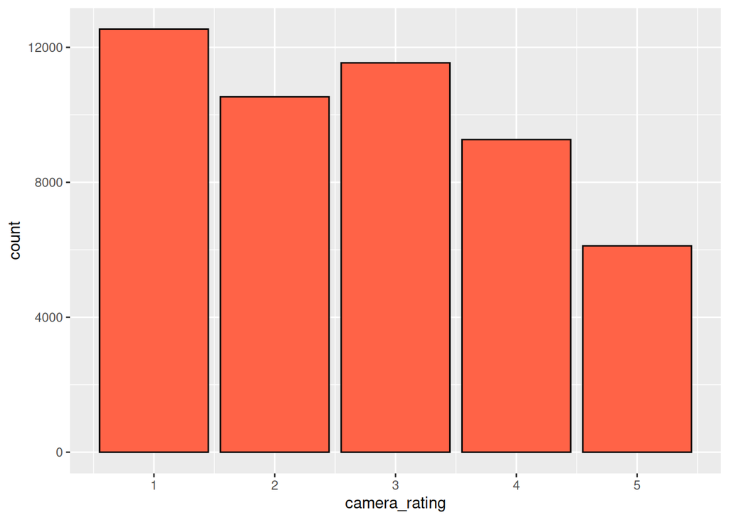

```r
ggplot(reviews, aes(x = camera_rating)) +
  geom_bar(fill = "tomato", color = "black")
```

### performance_rating

Ocena performansi uređaja. Ovde spadaju brzina uređaja i slicno.

I ovde je situacija gotovo identična, mali broj ljudi je prezadovoljan performansama uređaja.

```r
table(reviews$performance_rating)
```

```
##
##     1     2     3     4     5
## 12651 10351 11543  9276  6179
```

### design_rating

Ocena vezana za izgled samog uređaja – dimenzije, pozicija kamera, oblik i slične karakteristike. Gotovo identična situacija kao i sa prethodnim parametrima.

```r
table(reviews$design_rating)
```

```
##
##     1     2     3     4     5
## 12505 10656 11614  9086  6139
```

### display_rating

Ocena ekrana uređaja – veličina ekrana, jačina boja, oštrina, zaobljenost ivica i slično.

```r
table(reviews$display_rating)
```

```
##
##     1     2     3     4     5
## 12638 10442 11397  9264  6259
```

### review_length i word_count

Ove dve promenljive opisujemo zajedno jer se odnose na promenljivu review_text i predstavljaju neku vrstu metadata podataka – podaci koji opisuju karakteristike same promenljive.

Promenljiva review_length odnosi se na dužinu teksta – broj karaktera, dok promenljiva word_count predstavlja broj reči upotrebljenih u review-u.

### helpful_votes

Ovo je promenljiva koja označava koliko korisnika, koji su pročitali ovaj komentar odnosno samu ocenu, smatra istu korisnom.

možemo videti da broj glasova ide od 0 do 17, ali da najviše ima onih sa 2 – 5 glasova.

```r
summary(reviews$helpful_votes)
```

```
##    Min. 1st Qu.  Median    Mean 3rd Qu.    Max.
##   0.000   2.000   3.000   3.644   5.000  17.000
```

Još bolji prikaz raspodele možemo videti na grafiku ispod. Jako mali broj recenzija ima veliki broj glasova, najčešće je da recenzija ima od 2 do 5 glasova.

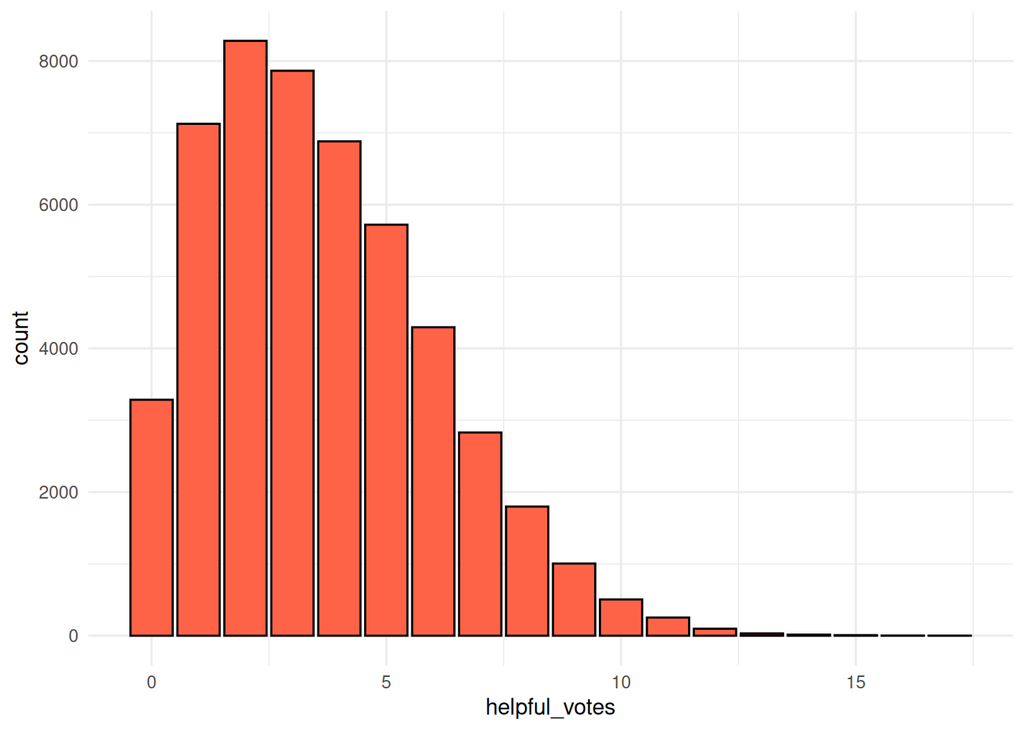

```r
ggplot(reviews, aes(x = helpful_votes)) +
  geom_bar(fill = "tomato", color = "black") +
  theme_minimal()
```

### source

Ovo je izvor, odnosno mesto gde je komentar ostavljen, a ujedno može predstavljati i platformu sa koje je proizvod kupljen jer se review najčešće ostavlja upravo na toj platformi.

možemo videti da ukupno imamo pet platformi i da je broj kupovina približan za svaku.

```r
table(reviews$source)
```

```
##
## AliExpress     Amazon    BestBuy       eBay   Flipkart
##      10015      10014       9941      10052       9978
```

Ovu promenljivu ćemo pretvoriti u faktorsku jer je po svojoj prirodi kategorijska i sastoji se od 5 kategorija: - AliExpress - Amazon - BestBuy - EBay - Flipkart

```r
reviews$source = factor(reviews$source)
```

## Provera ispravnosti price_usd

Pošto imam promenljive price_local i exchange_rate_to_usd, korisno je pogledati da li su sve vrednosti unutar price_usd odgovarajuće, tj. da li je konverzija ispravno odrađena.

Ovo je bitno radi dalje obrade podataka za slučaj da odlučimo da gledamo samo ovu promenljivu kao cenu koja je na istoj skali za sve redove.

To ćemo uraditi jednostavnim deljenjem price_local i exchange_rate_to_usd i proverom da li vrednost odgovara price_usd.

```r
reviews$custom_price_usd = round(reviews$price_local / reviews$exchange_rate_to_usd, 2)
```

Prikažimo prvih nekoliko elemenata, kako bismo videli da li je konverzija prošla kako treba.

```r
reviews[, c("price_usd", "custom_price_usd", "price_local", "currency", "exchange_rate_to_usd")]
```

| price_usd | custom_price_usd | price_local | currency | exchange_rate_to_usd |
| --- | --- | --- | --- | --- |
| 337.31 | 337.31 | 27996.73 | INR | 83.00 |
| 307.78 | 307.78 | 1754.35 | BRL | 5.70 |
| 864.53 | 864.53 | 71755.99 | INR | 83.00 |
| 660.94 | 660.94 | 2425.65 | AED | 3.67 |
| 792.13 | 792.13 | 4515.14 | BRL | 5.70 |
| 948.79 | 948.79 | 5408.10 | BRL | 5.70 |
| 420.13 | 420.13 | 1541.88 | AED | 3.67 |
| 1443.76 | 1443.76 | 2208.95 | AUD | 1.53 |
| 275.73 | 275.73 | 256.43 | EUR | 0.93 |
| 545.57 | 545.57 | 834.72 | AUD | 1.53 |

[output cut: 9990 more lines]

Pogledajmo ukupno koliko vrednosti u price_usd je tačno.

Vidimo da je cak 48 000 tačno, što znači da imamo samo 2 000 vrednosti koje imaju neki problem sa konverzijom valuta.

```r
sum(reviews$price_usd == reviews$custom_price_usd)
```

```
## [1] 48242
```

Potrebno je da dalje analiziramo ove vrednosti kako bismo videli da li su one u potpunosti pogrešne i onda odlučiti da li ćemo ove redove ukloniti ili izračunati na osnovu vrednosti u price_local i exchange_rate.

Najpre ćemo izdvojiti redove u kojima imamo neslaganja između price_usd i custom_price_usd.

```r
unmatching = reviews[reviews$price_usd != reviews$custom_price_usd, ]
```

Ono što primećujemo u prvih 10 redova jeste da je razlika u 0.01 što je verovatno posledica zaokruživanja vrednosti na dve decimale. Ovo je potrebno potvrditi i za ostatak vrednosti.

```r
unmatching[, c("price_usd", "custom_price_usd", "price_local", "currency", "exchange_rate_to_usd")]
```

|  | price_usd | custom_price_usd | price_local | currency | exchange_rate_to_usd |
| --- | --- | --- | --- | --- | --- |
| 11 | 462.30 | 462.29 | 360.59 | GBP | 0.78 |
| 26 | 506.50 | 506.51 | 471.05 | EUR | 0.93 |
| 68 | 300.64 | 300.65 | 279.60 | EUR | 0.93 |
| 111 | 652.80 | 652.79 | 509.18 | GBP | 0.78 |
| 118 | 1133.07 | 1133.06 | 883.79 | GBP | 0.78 |
| 133 | 297.34 | 297.35 | 231.93 | GBP | 0.78 |
| 135 | 770.21 | 770.22 | 716.30 | EUR | 0.93 |
| 175 | 817.84 | 817.85 | 637.92 | GBP | 0.78 |
| 176 | 249.61 | 249.62 | 194.70 | GBP | 0.78 |
| 186 | 660.50 | 660.49 | 614.26 | EUR | 0.93 |

[output cut: 1748 more lines]

Na ovaj način ćemo prebrojati koliko ima redova čija je razlika jednaka ili manja od 0.01.

Razlog zbog kog smo uveli 1e-8 jeste klasičan problem u računarskim naukama i radu sa decimalnim brojevima. Iako mi očekujemo da razlika bude 0.01, u realnosti to može biti i 0.0100001.

```r
sum(abs(abs(unmatching$price_usd - unmatching$custom_price_usd) - 0.01) < 1e-8)
```

```
## [1] 1758
```

Vrednost koju smo dobili i koja iznosi 1758 ćemo uporediti sa vrednošću ukupnog broja redova gde se ne poklapaju price_usd i custom_price_usd.

Vidimo da se broj redova poklapa.

Ovo je odlično, to znači da su sve lokalne valute ispravno konvertovane u USD.

```r
nrow(unmatching) - sum(abs(abs(unmatching$price_usd - unmatching$custom_price_usd) - 0.01) < 1e-8)
```

```
## [1] 0
```

Ovo je odlično, zato što smo sada sigurni u ispravnost ove promenljive i možemo je u daljem radu koristiti ukoliko bude potrebno.

## Odnos ciljane promenljive *rating* sa ostalim promenljivama u skupu

Svaku promenljivu u skupu podataka ćemo analizirati u odnosu na ciljnu promenljivu – rating kako bismo videli da li postoji veza u njihovim vrednostima. Na ovaj način, steći ćemo bolji uvid u prirodu odnosa promenljivih i kasnije odrediti prediktore.

[Izmenjeno]

### battery_life_rating

Pošto su obe promenljive kategorijske, grafikom ćemo lakše uočiti povezanost među njima.

možemo pogledati najpre tabelarni prikaz. Na X osi nalazi se promenljiva *rating* dok se na Y osi nalazi promenljiva *batery_life_rating*. možemo predstaviti ovaj odnos i grafikom.

```r
table(reviews$rating, reviews$battery_life_rating)
```

```
##
##        1    2    3    4    5
##   1 5318  928  122    9    0
##   2 4974 3319 1292  201   17
##   3 1991 4190 4351 1642  275
##   4  305 1890 4863 4777 2194
##   5    8  149  951 2501 3733
```

Ono što je primetno i u tabeli i na grafiku jeste da ocena *battery_life_rating*-a povlači i vrednost za *rating*. možemo jasno videti da ukoliko je ocena *battery_life_rating*-a niska, i ciljna promenljiva prati te vrednosti. Isto važi i ako su ocene visoke.

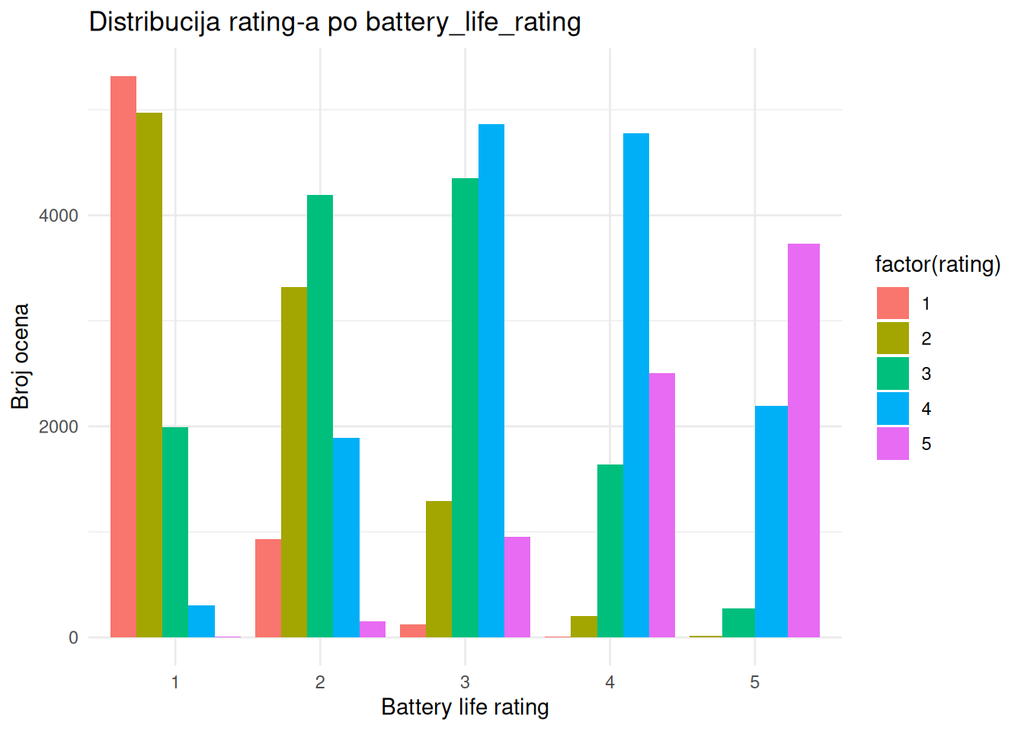

```r
ggplot(reviews, aes(x = factor(battery_life_rating), fill = factor(rating))) +
  geom_bar(position = "dodge") +
  labs(title = "Distribucija rating-a po battery_life_rating",
       x = "Battery life rating", y = "Broj ocena") +
  theme_minimal()
```

Dodatno, proverićemo pomoću Kruskal-Wallis testa zavisnost između dve promenljive. Ispod mozemo videti tri vrednosti: - *chi-squared* meri razliku izmedju grupa tj. kategorija unutar promenljive *battery_life_rating* - *df* oznacava koliko imamo kategorija u promenljivoj *battery_life_rating* - 1 - *p-value* je verovatnoca da se ovakav rezultat dobije slucajno

Nulta hipoteza: Ne postoji razlika u distribuciji *rating* na osnovu kategorija promenljive *battery_life_rating*. Ako je p-value mala, tada se nulta hipoteza odbacuje (postoji razlika između grupa).

Na osnovu ovih vrednosti, ovaj test pokazuje jasnu zavisnost između ove dve promenljive.

```r
# Korelacija
kruskal.test(rating ~ battery_life_rating, data = reviews)
```

```
##
##  Kruskal-Wallis rank sum test
##
## data:  rating by battery_life_rating
## Kruskal-Wallis chi-squared = 29631, df = 4, p-value < 2.2e-16
```

[Izmenjeno]

### camera_rating

Situacija sa odnosom između promenljivih camera_rating i rating je slična kao i prethodna. Veza između dve promenljive je jaka i linearna.

Tabelarni prikaz prikazuje povezanost između ove dve promenljive. Jasno se može videti da su retke visoke ocene za *rating* kada je *camera_rating* niska i obrnuto.

```r
table(reviews$rating, reviews$camera_rating)
```

```
##
##        1    2    3    4    5
##   1 5388  835  145    9    0
##   2 4823 3440 1324  203   13
##   3 2028 4254 4218 1694  255
##   4  290 1853 4810 4885 2191
##   5   13  152 1044 2475 3658
```

Grafički prikaz odnosа izmedju *rating* i *camera_rating* ukazuje na jasnu pozitivnu vezu – korisnici koji daju veću ocenu kameri najčešće daju i veći ukupni rating uređaja.

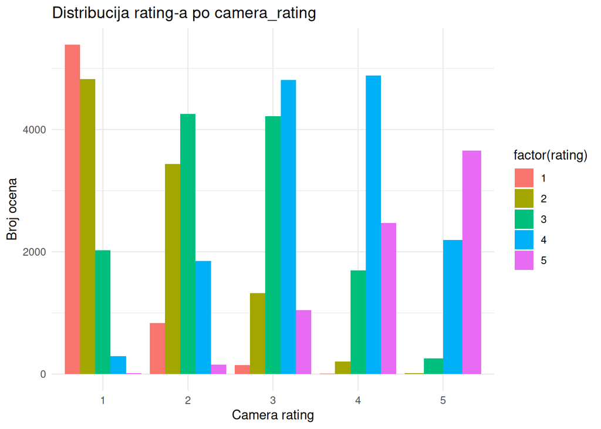

```r
ggplot(reviews, aes(x = factor(camera_rating), fill = factor(rating))) +
  geom_bar(position = "dodge") +
  labs(title = "Distribucija rating-a po camera_rating",
       x = "Camera rating", y = "Broj ocena") +
  theme_minimal()
```

Ispod možemo videti jasnu zavisnost i između ove dve promenljive, što je i grafik iznad prikazao.

```r
kruskal.test(rating ~ camera_rating, data = reviews)
```

```
##
##  Kruskal-Wallis rank sum test
##
## data:  rating by camera_rating
## Kruskal-Wallis chi-squared = 29517, df = 4, p-value < 2.2e-16
```

[Izmenjeno]

### performance_rating

Takođe i ovde grafički prikaz odnosа između rating i performance_rating ukazuje na jasnu pozitivnu vezu – korisnici koji daju veću ocenu performansama uređaja najčešće daju i veći ukupni rating uređaja.

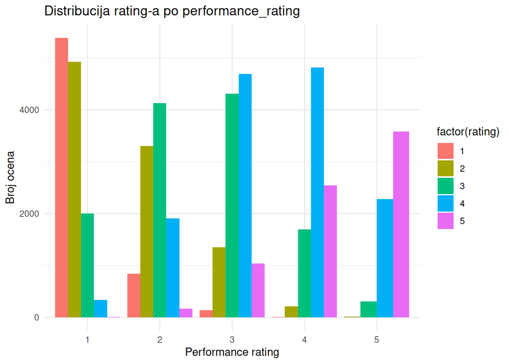

```r
ggplot(reviews, aes(x = factor(performance_rating), fill = factor(rating))) +
  geom_bar(position = "dodge") +
  labs(title = "Distribucija rating-a po performance_rating",
       x = "Performance rating", y = "Broj ocena") +
  theme_minimal()
```

Da bismo potvrdili zaključak sa grafika, možemo pogledati i rezultat Kurskal-Wallis testa. Na osnovu rezultata mozemo primetiti da je i ova promenljiva statistički značajna za promenljivu *rating*.

```r
kruskal.test(rating ~ performance_rating, data = reviews)
```

```
##
##  Kruskal-Wallis rank sum test
##
## data:  rating by performance_rating
## Kruskal-Wallis chi-squared = 29150, df = 4, p-value < 2.2e-16
```

Izmenjeno

## design_rating

Sa grafika možemo videti da osobe koje daju pozitivne ocene za dizajn uređaja, najčešće imaju i visoku krajnju ocenu za uređaj.

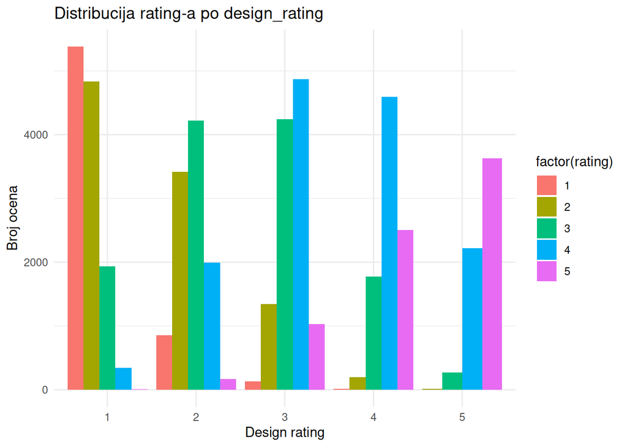

```r
ggplot(reviews, aes(x = factor(design_rating), fill = factor(rating))) +
  geom_bar(position = "dodge") +
  labs(title = "Distribucija rating-a po design_rating",
       x = "Design rating", y = "Broj ocena") +
  theme_minimal()
```

I za ovu promenljivu, vidi se visok stepen povezanosti sa ciljnom promenljivom.

```r
kruskal.test(rating ~ design_rating, data = reviews)
```

```
##
##  Kruskal-Wallis rank sum test
##
## data:  rating by design_rating
## Kruskal-Wallis chi-squared = 29092, df = 4, p-value < 2.2e-16
```

Izmenjeno

### display_rating

Još jedna promenljiva koja pokazuje umereno jaku zavisnost sa ciljnom promenljivom – *rating*.

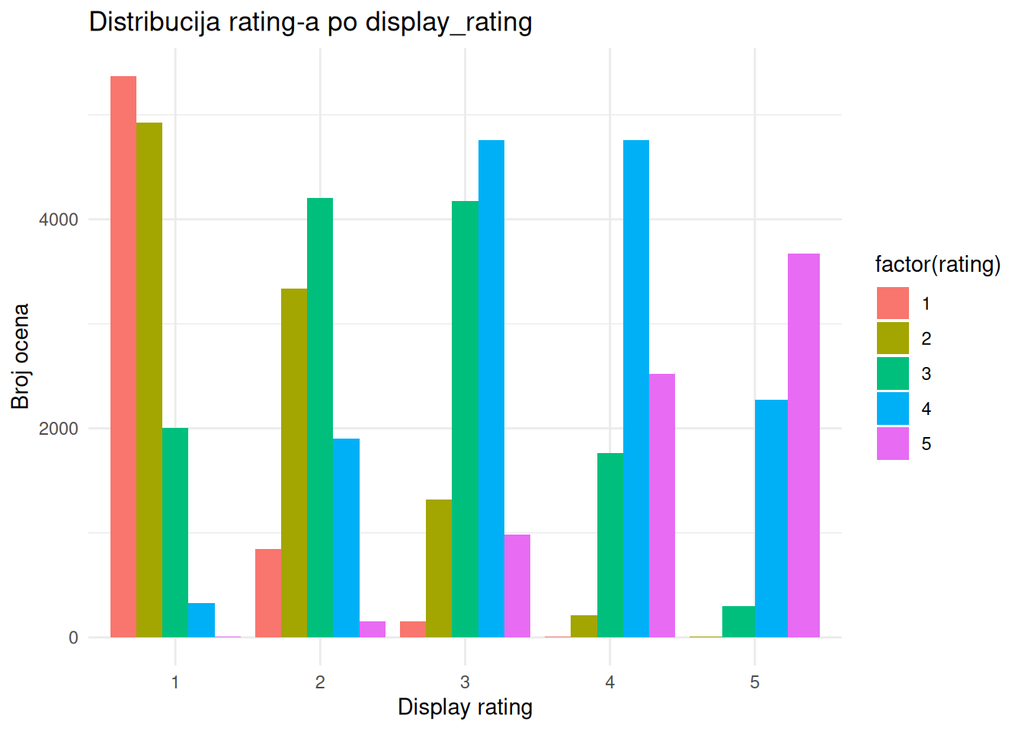

```r
ggplot(reviews, aes(x = factor(display_rating), fill = factor(rating))) +
  geom_bar(position = "dodge") +
  labs(title = "Distribucija rating-a po display_rating",
       x = "Display rating", y = "Broj ocena") +
  theme_minimal()
```

```r
kruskal.test(rating ~ display_rating, data = reviews)
```

```
##
##  Kruskal-Wallis rank sum test
##
## data:  rating by display_rating
## Kruskal-Wallis chi-squared = 29269, df = 4, p-value < 2.2e-16
```

## Dosadašnji zakljucak

Najpre smo uporedili zavisnost izmedju ukupne ocene samog uređaj i pojedinačnih ocena (po nekoj kategoriji). Primetno je da svih 5 pojedinačnih kategorija ocenjivanja pokazuju zavisnost sa krajnjom ocenom.

Ovo je donekle očekivano. Ono što je najčešća praksa prilikom ocenjivanja neke usluge/proizvoda jeste forma u kojoj je moguće oceniti neke od pojedinačnih kategorija od 1 – 5 (najčešće su to zvezdice ili tackice) i na kraju krajnju ocenu. Na osnovu svega ovoga, ovaj sled zavisnosti je očekivan.

Proverićemo i da li između ovih promenljivih postoji multikolinernost - odnosno međusobna zavisnost.

### price_usd

Ono što može uticati na ocenu samog uređaja je i cena. Neki uređaj je preplaćen, neki je jednostavno dosta jeftiniji u odnosu na ono što pruža. Možemo nacrtati grafik i pokušati da na njemu uočimo neku zavisnost.

Iako bismo možda očekivali da cena utiče na krajnju ocenu, tvrdnja da je skuplji telefon ujedno i bolji ne mora biti nužno tačna. Zbog toga, možemo videti da cena nema nikakav značaj na krajnju ocenu korisnika

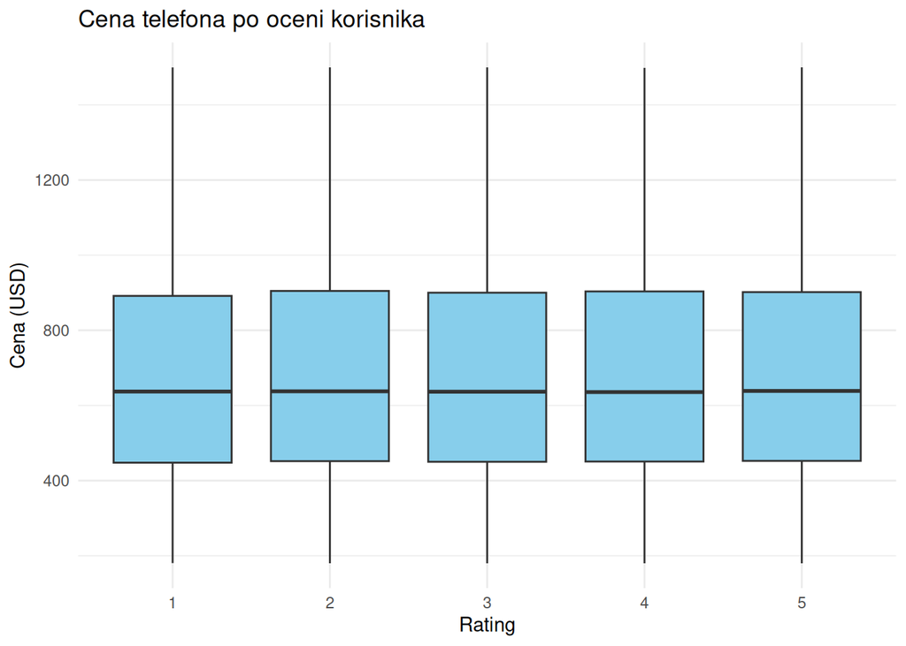

```r
ggplot(reviews, aes(x = factor(rating), y = price_usd)) +
  geom_boxplot(fill = "skyblue") +
  labs(
    x = "Rating",
    y = "Cena (USD)",
    title = "Cena telefona po oceni korisnika"
  ) +
  theme_minimal()
```

[Izmenjen grafik]

### brand

Uprkos tome što bismo možda očekivali da brend utiče na krajnju ocenu uređaja, grafik i podaci iz našeg skupa podataka ne govore u prilog tome.

Prema grafiku, ne postoji statistički značajna razlika u prosečnom rating-u između različitih brendova.

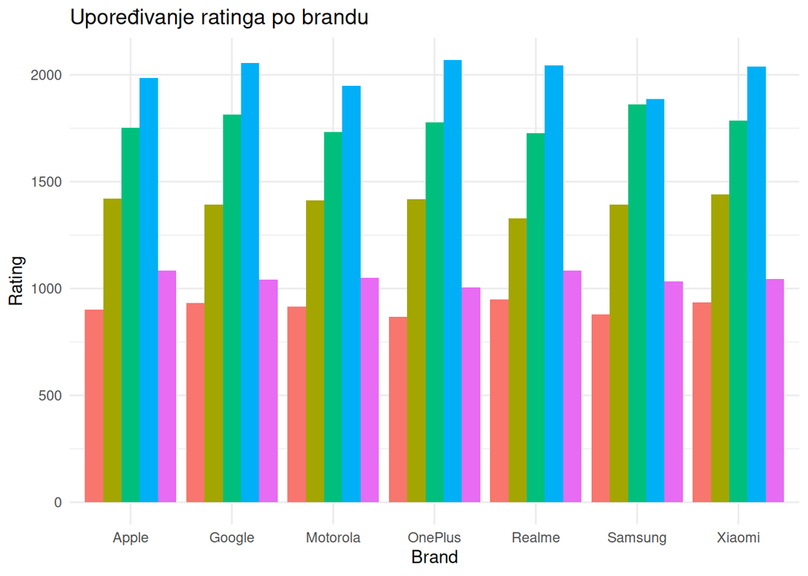

```r
ggplot(reviews, aes(x = factor(brand), fill = factor(rating))) +
  geom_bar(position = "dodge") +
  theme_minimal() +
  labs(
    title = "Upoređivanje ratinga po brandu",
    x = "Brand",
    y = "Rating"
  ) +
  theme(legend.position = "none")
```

[Izmenjeni grafici]

### sentiment

Sa grafika ispod možemo uočiti sledeće: - recenzije sa Negative sentimentom imaju uglavnom niske ocene (1–2) - recenzije sa Neutral sentimentom imaju ocene uglavnom oko 2–3 - recenzije sa Positive sentimentom imaju uglavnom visoke ocene (4–5)

Logično je da ce zadovoljni kupci davati veće ocene.

Ono što dodatno možemo uočiti na grafiku jesu potencijalni outlier-i za Negative i Neutral vrednosti promenljive Sentiment. Iako je većina korisnika koja je za Sentiment dala ocenu Negative ocenila proizvod sa 1 i 2, postoje korisnici koji su ipak ocenili sa 4. Kod neutral je slična situacija, najčešće ocene su 2 i 3, ali imamo i ocenu 5.

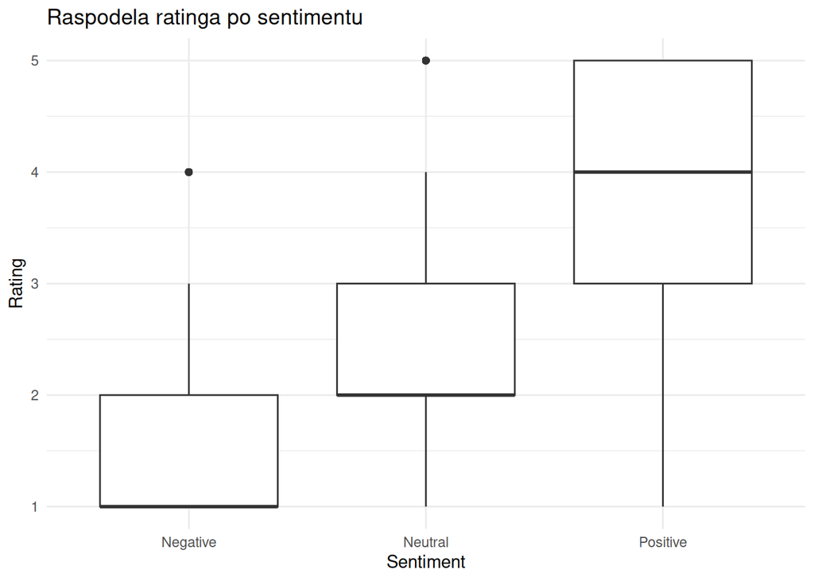

```r
ggplot(reviews, aes(x = sentiment, y = rating)) +
  geom_boxplot() +
  labs(title = "Raspodela ratinga po sentimentu",
       x = "Sentiment",
       y = "Rating") +
  theme_minimal()
```

Kako bismo bolje uvideli outlier-e, možemo za svaku kategoriju iz *sentiment*-a kreirati grafik. Ono što ćemo uključiti u sam grafik jeste model uređaja, jer se može da dogoditi da je to outlier u opštem skupu podataka, ali ne i za model uređaja.

## Grafički prikaz outlier-a

Pošto imamo veliki broj kategorija za modele, a želimo da vidimo outlier-e po kategoriji modela i po kategoriji sentiment-a, razdvojićemo grafike za svaku pojedinačnu vrednosti *sentiment*-a.

### Negative sentiment

Najpre ćemo prikazati negativne vrednosti ove promenljive. Na grafiku ispod možemo videti da je najveći broj korisnika, kada je izrazio opste nezadovoljstvo proizvodom, dao i negativnu konačnu ocenu, odnosno 1 ili 2. Međutim, ima dosta korisnika koji su dali i prosečnu ocenu - 3. One ocene, koje možemo smatrati outlier-ima su ocene 4. Ovo su vrednosti koje odskaču na grafiku i predstavljaju outlier-e.

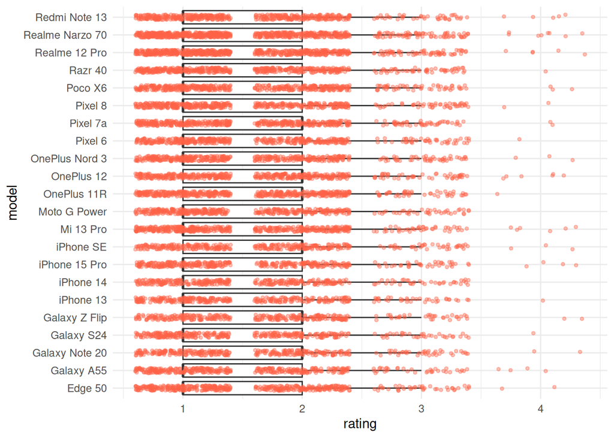

```r
negative_sentiment_df = reviews %>%
  filter(sentiment == "Negative")

ggplot(negative_sentiment_df, aes(x = model, y = rating)) +
  geom_boxplot(outlier.shape = NA) +
  geom_jitter(
    color = "tomato",
    width = 0.15,
    alpha = 0.4,
    size = 1
  ) +
  coord_flip() +
  theme_minimal()
```

Pošto smo preko grafika zaključili da su outlier-i one vrednosti koje imaju *rating* preko 3, možemo prebrojati koliko ima tih vrednosti. Vidimo da postoji 62 outlier-a kada je *sentiment* negativan.

```r
negative_sentiment_outlier_num = sum(negative_sentiment_df$rating > 3)

negative_sentiment_outlier_num
```

```
## [1] 62
```

### Neutral sentiment

Sada ćemo pogledati sta se dešava sa neutralnim opštim iskustvom o modelu uređaja.

Na grafiku ispod možemo primetiti da je slabija grupacija kada je vrednost za *rating* veća od 4. Tako da možemo smatrati da su u ovoj kategoriji - kada je sentiment neutralan, outlier-i kreću kao vrednosti za *rating* veće od 4.

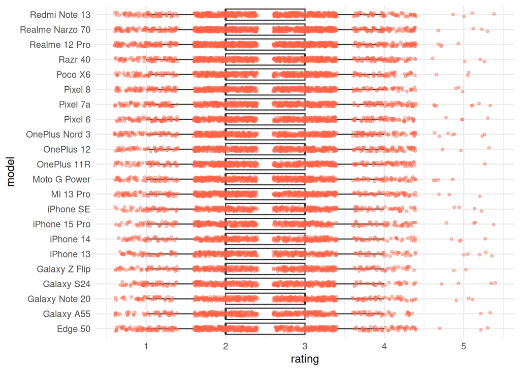

```r
neutral_sentiment_df = reviews %>%
  filter(sentiment == "Neutral")

ggplot(neutral_sentiment_df, aes(x = model, y = rating)) +
  geom_boxplot(outlier.shape = NA) +
  geom_jitter(
    color = "tomato",
    width = 0.15,
    alpha = 0.4,
    size = 1
  ) +
  coord_flip() +
  theme_minimal()
```

Kao i sa prethodnom kategorijom, izračunaćemo o kom broju outlier-a se radi. Ovde imamo nešto više ovih vrednosti, ali obzirom da nam skup podataka ima 50 hiljada redova, možemo reći da to nije veliki broj outlier-a.

```r
neutral_sentiment_outlier_num = sum(neutral_sentiment_df$rating > 4)

neutral_sentiment_outlier_num
```

```
## [1] 82
```

### Positive sentiment

Poslednja, treća kategorija za sentiment su pozitivne vrednosti, odnosno pozitivan opšti utisak o uređaju.

Izdvojimo ove vrednosti u poseban data frame i nacrtajmo grafik kako bismo vizuelno uočili outlier-a.

Zahvaljujući grafiku, možemo videti da su ovde outlier-i vrednosti koje imaju *rating* manji od 2, što je donekle i očekivano, ali grafik to potvrđuje.

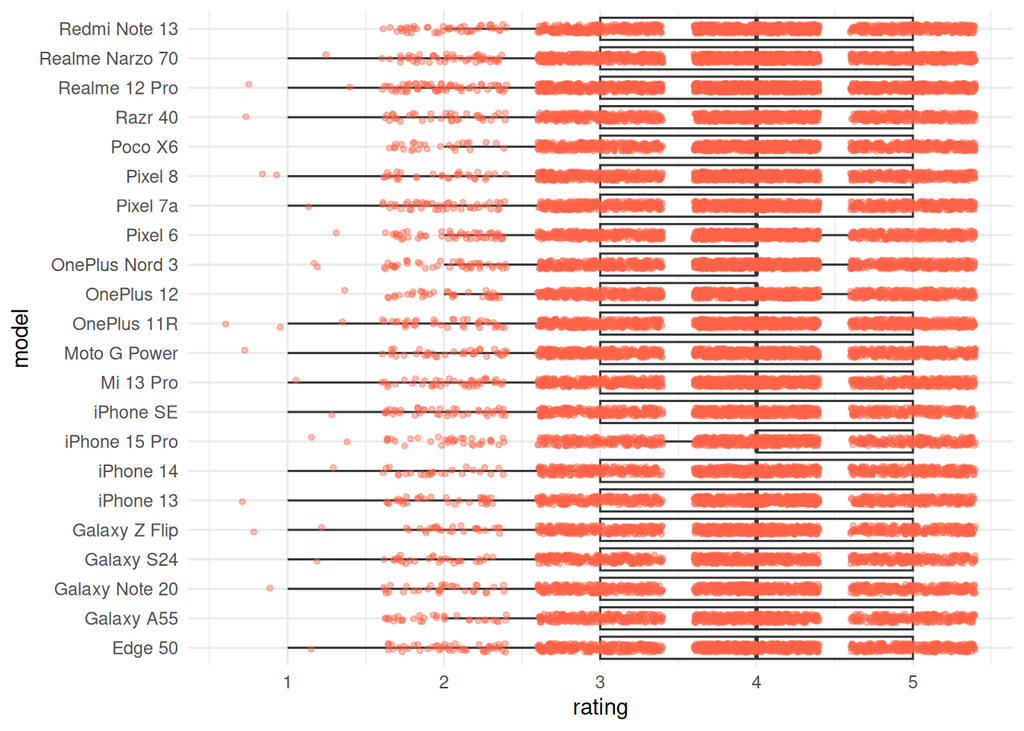

```r
positive_sentiment_df = reviews %>%
  filter(sentiment == "Positive")

ggplot(positive_sentiment_df, aes(x = model, y = rating)) +
  geom_boxplot(outlier.shape = NA) +
  geom_jitter(
    color = "tomato",
    width = 0.15,
    alpha = 0.4,
    size = 1
  ) +
  coord_flip() +
  theme_minimal()
```

Na osnovu grafika isto možemo videti da nema previše outlier-a u ovoj kategoriji, ali je najpreciznije izračunati tačnu vrednost.

```r
positive_sentiment_outlier_num = sum(positive_sentiment_df$rating < 2)

positive_sentiment_outlier_num
```

```
## [1] 26
```

Kada saberemo broj outlier-a za svaku kategoriju promenljive *sentiment* možemo videti da u našem skupu podataka imamo 170 outlier-a. Ovaj broj outlier-a predstavlja manje od 1% ukupnih observacija u našem skupu podataka, preciznije ~ 0.34%.

```r
outlier_num_total = negative_sentiment_outlier_num + neutral_sentiment_outlier_num + positive_sentiment_outlier_num

outlier_num_total
```

```
## [1] 170
```

[Dodato]

## Uklanjanje outlier-a iz skupa podataka

Pošto outlier-i predstavljaju zanemarljivu količinu podataka u našem skupu podataka, a mogu imati značajan uticaj na preciznost samog modela, uklonićemo ih iz našeg skupa podataka.

Sumirajmo ono po čemu treba izbaciti outlier-e: - Kada *sentiment* ima vrednost *Negative* i *rating* veći od 3, te observacije se smatraju outlier-ima - Kada *sentiment* ima vrednost *Neutral* i *rating* veći od 4, te observacije se smatraju outlier-ima - Kada *sentiment* ima vrednost *Positive* i *rating* manji od 2, te observacije se smatraju outlier-ima

Uklonimo ovakve vrednosti iz skupa podataka.

```r
reviews = reviews %>%
  filter(!(sentiment == "Negative" & rating > 3))

reviews = reviews %>%
  filter(!(sentiment == "Neutral" & rating > 4))

reviews = reviews %>%
  filter(!(sentiment == "Positive" & rating < 2))
```

Proverimo da li su uspešno uklonjeni outlier-i proverom broja redova u skupu podataka. Vidimo da je broj redova smanjen, što znači da smo uspešno uklonili outlier-e.

```r
dim(reviews)
```

```
## [1] 49830    26
```

### age

Sada ćemo proveriti age, jer starost korisnika može uticati na ocenu, zato što različite generacije različito doživljavaju telefone.

Međutim, na osnovu grafika možemo zaključiti da starost korisnika nema značajan uticaj na ocenu uređaja.

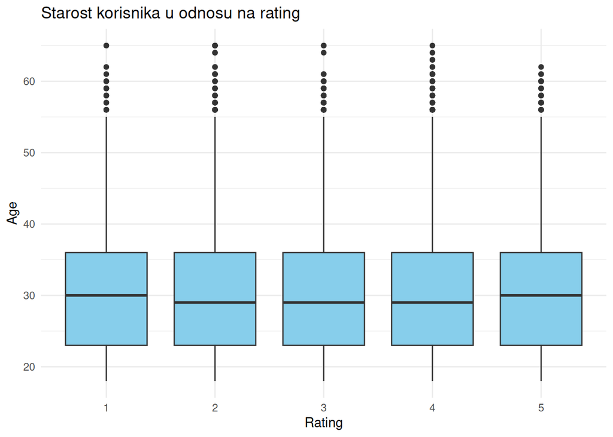

```r
ggplot(reviews, aes(x = factor(rating), y = age)) +
  geom_boxplot(fill = "skyblue") +
  labs(
    x = "Rating",
    y = "Age",
    title = "Starost korisnika u odnosu na rating"
  ) +
  theme_minimal()
```

Na osnovu grafika i rezultata funkcije za određivanje korelacije između dve promenljive, možemo zaključiti da ova promenljiva nije preterano značajna za odredjivanje ciljne promenljive.

```r
cor(reviews$age,reviews$rating)
```

```
## [1] 0.007060725
```

Međutim, pošto je ovo numerička vrednost, možemo godine svrstati u tri kategorije - Mladi, Srednje godine i Starije doba

```r
reviews = reviews %>%
  mutate(age_category = case_when(
    age >= 18 & age < 30 ~ "Young age",
    age >= 30 & age <= 55 ~ "Middle age",
    age > 55 ~ "Senior age"
  ))
```

Ovako kreiranu promenljivu ćemo pretvoriti u faktorsku, odnosno kategorijsku.

```r
reviews$age_category = factor(reviews$age_category)
```

Sada ćemo uporediti ciljnu promenljivu rating sa age_category.

```r
table(reviews$age_category, reviews$rating)
```

```
##
##                 1    2    3    4    5
##   Middle age 3162 4833 6067 6916 3657
##   Senior age   20   41   43   54   31
##   Young age  3169 4929 6339 6997 3572
```

Na osnovu ove tabele, možemo videti da sve uzrasne grupe ocenjuju uređaje najčešće sa 3 i 4, što je negde prosečna ocena. Dodatno, na osnovu ove tabele možemo zaključiti da odsupanja na prethodnom grafiku – koja liče na outlier-e to nisu. To je starija populacija koje ima dosta manje u odnosu na ostale dve.

[Izmenjen grafik]

### source

Sada ćemo proveriti odnos source i rating. Source predstavlja mesto gde je komentar ostavljen, a ujedno može predstavljati i platformu sa koje je proizvod kupljen. Platforma na kojoj je recenzija ostavljena može biti indikator i kvaliteta samog uređaja (npr. prodaja kopija na određenim sajtovima).

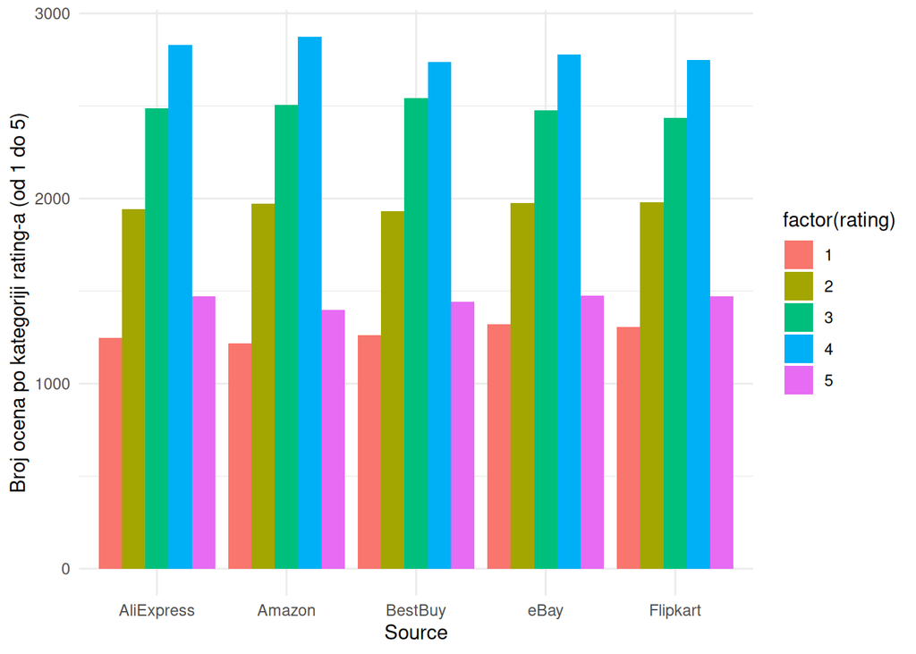

```r
ggplot(reviews, aes(x = source, fill = factor(rating))) +
  geom_bar(position = "dodge") +
  labs(
    x = "Source",
    y = "Broj ocena po kategoriji rating-a (od 1 do 5)"
  ) +
  theme_minimal()
```

```r
anova_test <- aov(rating ~ source, reviews)
summary(anova_test)
```

```
##                Df Sum Sq Mean Sq F value Pr(>F)
## source          4      4   1.078   0.693  0.597
## Residuals   49825  77492   1.555
```

Ne postoji statistički značajna razlika u prosečnim ocenama između različitih platformi. To znači da source nije presudan faktor u ocenjivanju uređaja.

[Izmenjen grafik]

### verified_purchase

Hoćemo sada da proverimo verified_purchase u odnosu na rating, zato što verifikovana kupovina povećava kredibilitet ocene. Ljudi koji su stvarno kupili uređaj obično daju realnije ocene, manje lažnih bot komentara.

Iako smo pretpostavili da verifikovane recenzije imaju veću kredibilnost, analiza pokazuje da prosečne ocene ne variraju značajno u zavisnosti od statusa kupovine.

Zbog ove analize, nećemo isključiti vrednosti sa neverifikovanom recenzijom iz skupa podataka zato što, kao sto vidimo na grafiku ispod, nema značajnog uticaja.

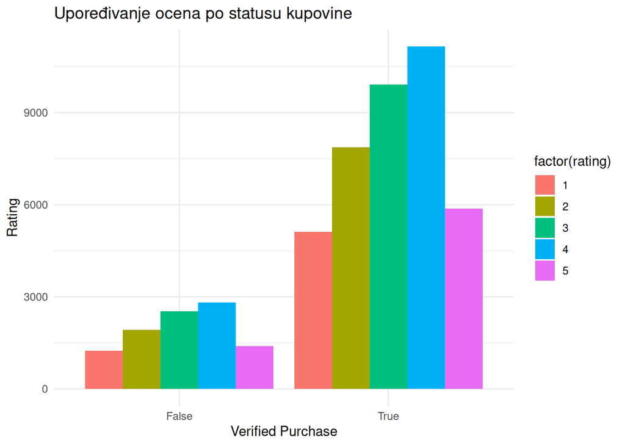

```r
ggplot(reviews, aes(x = factor(verified_purchase), fill = factor(rating))) +
  geom_bar(position = "dodge") +
  labs(
    title = "Upoređivanje ocena po statusu kupovine",
    x = "Verified Purchase",
    y = "Rating"
  ) + theme_minimal()
```

[Izmenjen grafik]

### helpful_votes

Vidimo da je promenljiva helpful_votes značajna u određenoj meri. Uređaji koji imaju veci broj “korisnih glasova” na recenzijama uglavnom imaju nešto viši rating.

Znači popularnije recenzije su često one koje su dale dobru ocenu proizvodu.

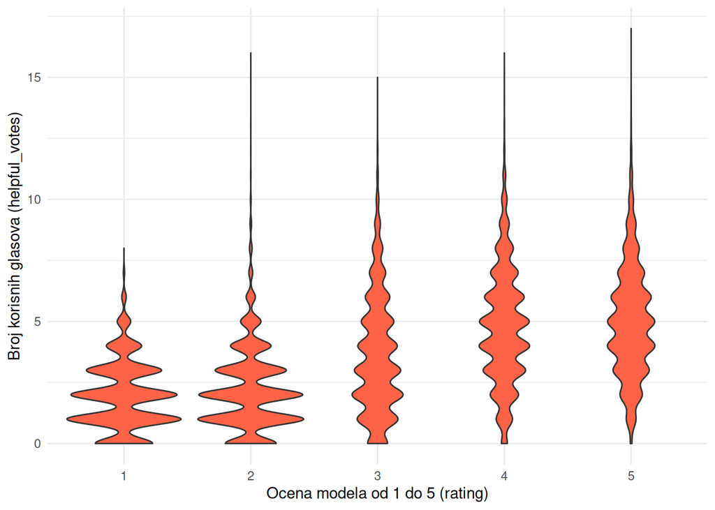

```r
ggplot(reviews, aes(x = factor(rating), y = helpful_votes)) +
  geom_violin(fill = "tomato") +
  labs(
    x = "Ocena modela od 1 do 5 (rating)",
    y = "Broj korisnih glasova (helpful_votes)"
  ) +
  theme_minimal()
```

```r
cor(reviews$helpful_votes, reviews$rating)
```

```
## [1] 0.4652454
```

### review_date

Deluje da datum recenzije nema nikakav značaj na ukupan rating, pogledaćemo i prosečan rating po mesecima.

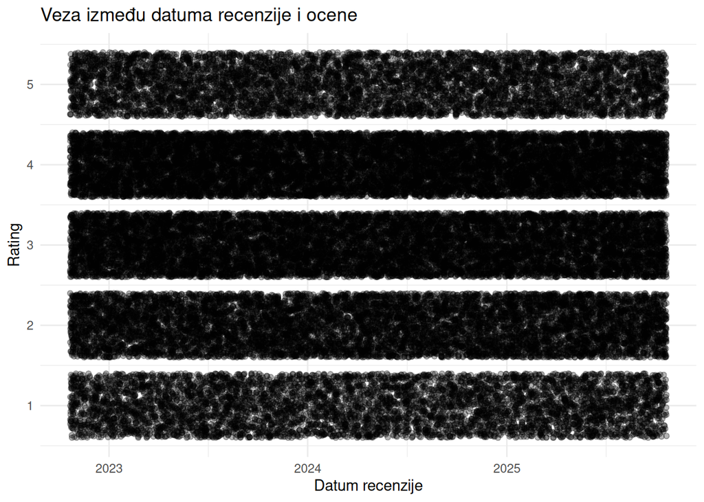

```r
reviews$review_date <- as.Date(reviews$review_date)

ggplot(reviews, aes(x = review_date, y = rating)) +
  geom_jitter(alpha = 0.3) +
  labs(
    title = "Veza između datuma recenzije i ocene",
    x = "Datum recenzije",
    y = "Rating"
  ) +
  theme_minimal()
```

Najpre ćemo napraviti malu pripremu podataka za iscrtavanje grafika.

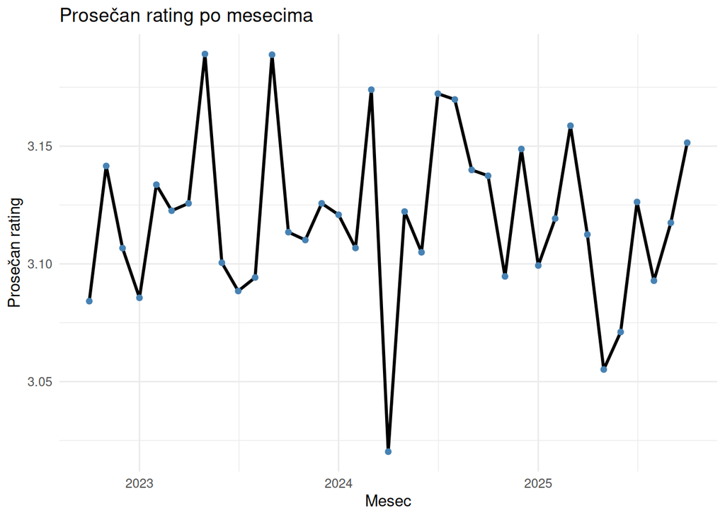

```r
df_month <- reviews %>%
  mutate(month = floor_date(review_date, "month")) %>%
  group_by(month) %>%
  summarise(avg_rating = mean(rating))

ggplot(df_month, aes(x = month, y = avg_rating)) +
  geom_line(size = 1) +
  geom_point(color = "steelblue") +
  labs(
    title = "Prosečan rating po mesecima",
    x = "Mesec",
    y = "Prosečan rating"
  ) +
  theme_minimal()
```

Sa grafika možemo videti da su podaci prilično nasumično raspoređeni, takođe opseg prosečnog rating-a je od 3.00 do 3.20, što je ne toliko značajna razlika.

Ova promenljiva nam verovatno neće biti značajna u predviđanju.

[Izmenjen grafik]

### language

Na osnovu grafika ispod, možemo zaključiti da svi jezici daju proporcionalno iste glasove. Najviše ima onih sa *rating*-om 4 i 3, pa zatim ostalih. Za svaki jezik možemo videti da je struktura identična, samo za englesko govorno područje ima više recenzije pa je zbog toga prividno drugačije. Oblik zastupljenosti ocena je identičan za sve jezike.

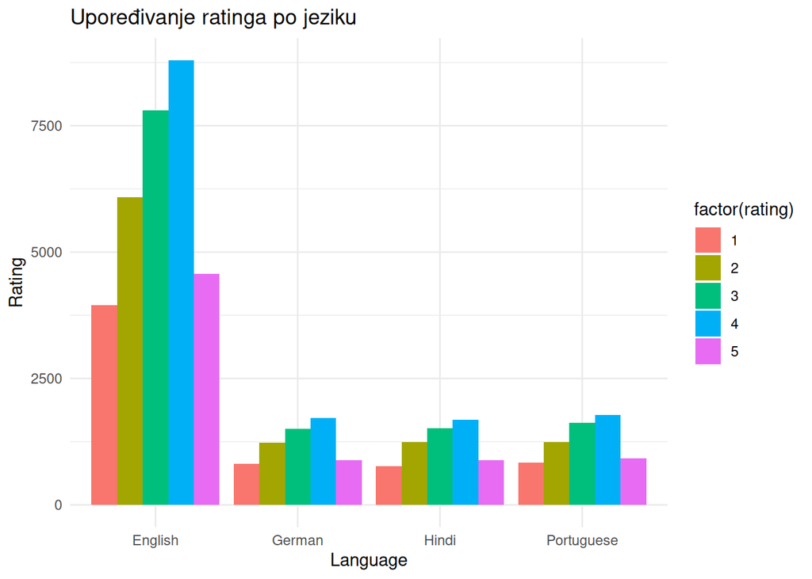

```r
ggplot(reviews, aes(x = factor(language), fill = factor(rating))) +
  geom_bar(position = "dodge") +
  theme_minimal() +
  labs(
    title = "Upoređivanje ratinga po jeziku",
    x = "Language",
    y = "Rating"
  )
```

[Izmenjen grafik]

### country

Još jedna promenljiva koja ne pokazuje nikakav uticaj na našu ciljnu promenljivu – rating. Na grafiku se jasno videi da je *rating* približno istog oblika za sve države.

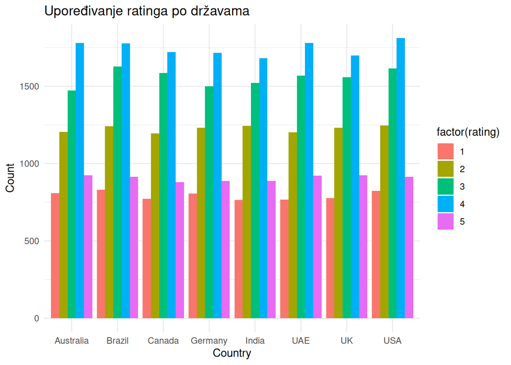

```r
ggplot(reviews, aes(x = factor(country), fill = factor(rating))) +
  geom_bar(position = "dodge") +
  theme_minimal() +
  labs(
    title = "Upoređivanje ratinga po državama",
    x = "Country",
    y = "Count"
  )
```

#Feature selection

Prilikom izbora prediktora za određivanje naše ciljne promenljive – rating, primenićemo dva pristupa.

Prvi pristup biće zasnovan na Feature importance-u Random Forest modela koji će nam pomoći u selekciji najvažnih modela, a drugi je naša selekcija na osnovu upoređivanja odnosa svake promenljive sa ciljnom.

Podsetimo se još jednom strukture našeg skupa podataka, ali sada u nešto izmenjenim tipovima promenljivih nakon inicijalne obrade (pretvaranja u faktorske promenljive, čišćenje od specijalnih karaktera, pretvaranje u numeričke kategorije i slično).

```r
str(reviews)
```

```
## 'data.frame':    49830 obs. of  27 variables:
##  $ review_id           : int  1 2 3 4 5 6 7 8 9 10 ...
##  $ customer_name       : chr  "Aryan Maharaj" "Davi Miguel Sousa" "Pahal Balay" "David Guzman" ...
##  $ age                 : int  45 18 27 19 38 38 40 39 32 31 ...
##  $ brand               : Factor w/ 7 levels "Apple","Google",..: 5 5 2 7 3 1 4 1 5 4 ...
##  $ model               : Factor w/ 22 levels "Edge 50","Galaxy A55",..: 20 20 15 22 1 7 13 9 20 14 ...
##  $ price_usd           : num  337 308 865 661 792 ...
##  $ price_local         : num  27997 1754 71756 2426 4515 ...
##  $ currency            : Factor w/ 8 levels "AED","AUD","BRL",..: 7 3 7 1 3 3 1 2 5 2 ...
##  $ exchange_rate_to_usd: num  83 5.7 83 3.67 5.7 5.7 3.67 1.53 0.93 1.53 ...
##  $ rating              : int  2 4 4 3 3 5 3 2 4 3 ...
##  $ review_text         : chr  "Not worth the money spent. Wouldn’t recommend." "Absolutely love this phone! The camera is next level. Absolutely worth it!" "Loving the clean UI and fast updates. Loving it so far!" "Build quality feels solid and durable. No regrets buying this one." ...
##  $ sentiment           : chr  "Negative" "Positive" "Positive" "Positive" ...
##  $ country             : Factor w/ 8 levels "Australia","Brazil",..: 5 2 5 6 2 2 6 1 4 1 ...
##  $ language            : Factor w/ 4 levels "English","German",..: 3 4 3 1 4 4 1 1 2 1 ...
##  $ review_date         : Date, format: "2023-11-06" "2023-03-30" ...
##  $ verified_purchase   : Factor w/ 2 levels "False","True": 2 2 2 1 2 1 1 2 1 2 ...
##  $ battery_life_rating : int  1 3 3 1 3 5 3 2 4 2 ...
##  $ camera_rating       : int  1 2 5 3 3 4 3 1 3 2 ...
##  $ performance_rating  : int  3 4 3 2 2 5 2 2 2 3 ...
##  $ design_rating       : int  2 3 2 1 2 5 1 2 3 3 ...
##  $ display_rating      : int  1 2 4 2 1 4 2 2 3 2 ...
##  $ review_length       : int  46 74 55 66 73 70 58 56 60 72 ...
##  $ word_count          : int  7 12 11 11 12 13 10 8 12 12 ...
##  $ helpful_votes       : int  1 5 8 3 0 6 2 3 8 4 ...
##  $ source              : Factor w/ 5 levels "AliExpress","Amazon",..: 2 5 1 2 3 1 4 2 4 3 ...
##  $ custom_price_usd    : num  337 308 865 661 792 ...
##  $ age_category        : Factor w/ 3 levels "Middle age","Senior age",..: 1 3 3 3 1 1 1 1 1 1 ...
```

## Feature importance Random Forest modela

Random Forest je model koji kombinuje veći broj stabala odlučivanja i pogodan je za probleme klasifikacije. Za problem klasifikacije – kakav je naš problem, ne možemo koristiti Lasso i Ridge regularizaciju, ali možemo iskoristit neke benefite Random forest modela.

Upoređivanjem svake promenljive sa ciljnom, došli smo do zaključka koje promenljive dosta dobro opisuju ciljnu promenljivu. Najznačajniji prediktori su: - *camera_rating* - *display_rating* - *batery_life_rating* - *design_rating* - *perfomance_rating* - *sentiment*

Primenićemo Random forest model nad celokupnim skupom podataka i analizirati rezultat njegove feature importance opcije da vidimo koje prediktore on identifikuje kao značajne.

```r
rf_model <- randomForest(
  x = subset(reviews, select = -rating),
  y = as.factor(reviews$rating),
  importance = TRUE
)
```

```r
importance(rf_model)
```

```
##                              1          2          3           4          5
## review_id            -2.204156 -0.7355656  0.2601624 -0.08556751  1.1586072
## customer_name        -1.117008  1.8121514  1.2281244  0.83252119 -3.4231842
## age                   4.299227  0.3353959 -1.0039552  2.44807360 -0.2749596
## brand                 9.868500  7.9954773  8.5725321 14.94353160  6.5978065
## model                 9.774898  6.7744616  4.8406776 10.32307770  4.2479031
## price_usd            19.057061 12.4362635 16.5189613 23.27544577 16.0554364
## price_local          17.845764  9.8582456 11.4823221 18.88981467 11.2044392
## currency              4.324451  1.1570012  1.7726147  5.85702008  3.6094672
## exchange_rate_to_usd  7.216225  3.0098046  3.3220539  5.21966786  4.6987394
## review_text          13.531040 15.9545640 15.0573719 11.09228710  6.7376760
## sentiment            76.051340 88.5217082 33.4952250 65.52146346 63.5739727
## country               3.442351  0.3932828  0.5879571  6.37557148  2.1576818
## language              3.733681  0.6098753  1.2383625  2.77425828  0.1561642
## review_date           1.018036  0.9332383 -1.0165523  0.93035107 -0.2471206
## verified_purchase    -1.326763  0.3088814 -0.5535200 -0.57256394  0.7165787
## battery_life_rating  86.294252 53.0059875 56.8079503 61.94033534 98.3909042
## camera_rating        95.416118 49.6661346 65.9804644 70.91810311 86.4991415
## performance_rating   96.401871 54.2928966 58.0513883 59.80874586 84.6026362
## design_rating        91.805535 51.1131121 52.0929257 56.57637285 93.2099675
## display_rating       94.995435 52.0733506 56.4079227 65.95068379 85.3535189
## review_length        21.862350 12.4299621 17.2380645 15.23793231  4.7350284
## word_count           11.317118  7.0958117  9.4713783 12.73241116  8.2074800
## helpful_votes        22.725218 17.2397372 16.7998040 23.43238042 15.8016737
## source                2.023052 -0.4531475 -1.4442477  1.29168035  0.6205958
## custom_price_usd     21.190850 13.0197055 17.3468109 23.23716858 15.9535408
## age_category          3.559653  0.1753757 -0.9511195  4.73184836  0.3224824
##                      MeanDecreaseAccuracy MeanDecreaseGini
## review_id                      -0.5565772        1243.3382
## customer_name                   0.2906665        1242.2826
## age                             2.4986640         968.5583
## brand                          22.2999991         770.3263
## model                          16.5749724        2245.7510
## price_usd                      43.4138713        1060.2833
## price_local                    33.9847820        1076.1384
## currency                        7.3422892         850.7457
## exchange_rate_to_usd           10.6250587         326.9524
## review_text                    17.9254198        1150.9910
## sentiment                      99.8594574        3545.3242
## country                         6.3973998         850.7404
## language                        4.0282950         184.5615
## review_date                     0.7212765        1246.0433
## verified_purchase              -0.6049159         134.7356
## battery_life_rating           113.6555305        3611.7411
## camera_rating                 109.2849907        3721.4203
## performance_rating            115.7359930        3327.1367
## design_rating                 119.5985875        3272.0845
## display_rating                114.7676193        3402.7920
## review_length                  29.9717342        1049.6831
## word_count                     16.0575232         677.5407
## helpful_votes                  34.4691199        1016.9270
## source                          0.7386233         818.9031
## custom_price_usd               44.6846815        1065.0651
## age_category                    3.6997936         137.6700
```

Na slici iznad možemo videti dve vrednosti koje nam mogu pomoci u određivanju prediktora:

- *Mean Decrease Acuracy* koji nam govori koliko bii se smanjila tačnost modela ako bi se ta promenljiva izmenila (da sve ostale promenljive ostanu iste, ali da se samo ta promenljiva značajno izmeni)
- *Mean Decrease Gini* ili Gini indeks meri koliko promenljiva doprinosi čistoći cvorova (veća vrednost znači da je promenljiva značajna i da dobro razdvaja stablo odlučivanja na klase)

Na osnovu ove dve vrednosti, možemo zaključiti da je ovaj model odredio iste prediktore kao značajne kao sto smo i mi odradili ručnom analizom pojedinačnih promenljivih sa ciljnom.

Ove dve vrednosti, zajedno sa promenljivama možemo predstaviti i grafički kako bismo vizuelno lakše primetili razliku. One promenljive čije vrednosti značajno odskaču u odnosu na ostale su upravo prediktori koje smo i ručno ustanovili.

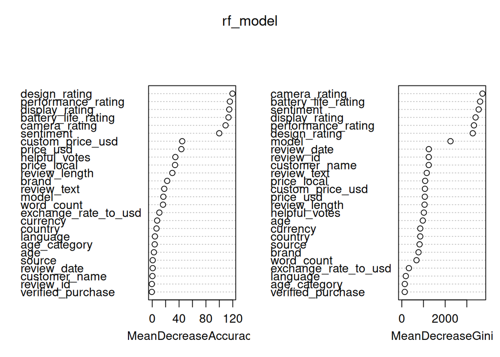

```r
varImpPlot(rf_model)
```

Pošto nam se poklapa izbor prediktora, zaključujemo da su ovih 6 promenljivih korisne za određivanje ciljne promenljive i njih ćemo izvući u zaseban skup podataka koji će sadržati samo promenljive bitne za predikciju naše ciljne promenljive i samu ciljnu promenljivu.

```r
reviews_important_vars = reviews[, c("camera_rating", "display_rating", "battery_life_rating", "design_rating", "performance_rating", "sentiment", "rating")]

names(reviews_important_vars)
```

```
## [1] "camera_rating"       "display_rating"      "battery_life_rating"
## [4] "design_rating"       "performance_rating"  "sentiment"
## [7] "rating"
```

[Dodato]

## Provera multikolinearnosti izmedju prediktora

Pošto smo odabrali skup prediktora koji će potencijalno dobro opisati model, treba proveriti da li između tih prediktora postoji neka vrsta multikolinearnosti. Modeli mogu dati pogresne rezultate zbog pristustva multikolinearnosti među prediktorima, pa je cilj ove analize da takve prediktore uoči i odluči šta će raditi sa njima ukoliko postoje.

Pogledajmo strukturu promenljivih unutar *reviews_important_vars*.

```r
str(reviews_important_vars)
```

```
## 'data.frame':    49830 obs. of  7 variables:
##  $ camera_rating      : int  1 2 5 3 3 4 3 1 3 2 ...
##  $ display_rating     : int  1 2 4 2 1 4 2 2 3 2 ...
##  $ battery_life_rating: int  1 3 3 1 3 5 3 2 4 2 ...
##  $ design_rating      : int  2 3 2 1 2 5 1 2 3 3 ...
##  $ performance_rating : int  3 4 3 2 2 5 2 2 2 3 ...
##  $ sentiment          : chr  "Negative" "Positive" "Positive" "Positive" ...
##  $ rating             : int  2 4 4 3 3 5 3 2 4 3 ...
```

Vidimo da je jedino još promenljiva *sentiment* faktorskog tipa. Nju ćemo prebacitit u numeričku.

```r
reviews_important_vars$sentiment = as.numeric(factor(reviews_important_vars$sentiment))
```

Pokrenimo funckiju *cor()* nad skupom podataka koji sadrži odabrane prediktore i ciljnu promenljivu.

Trenutno nas ne zanima korelacija izmedju promenljive *rating* i ostalih zato što je to ciljna promenljiva tako da cemo je izbaciti. Ono što nas zanima jeste da li je vrednost izmedju dva prediktora veća od 0.8 što bi ukazivalo na visoku multikolineranost.

U tabeli ispod možemo videti da je korelisanost između prediktora maksimalno 0.60 što je umerena korelacija i ne predstavlja problem u našem skupu podatka.

```r
cor = cor(reviews_important_vars[, -ncol(reviews_important_vars)], method = "spearman")

cor
```

```
##                     camera_rating display_rating battery_life_rating
## camera_rating           1.0000000      0.5855326           0.5924905
## display_rating          0.5855326      1.0000000           0.5880618
## battery_life_rating     0.5924905      0.5880618           1.0000000
## design_rating           0.5847386      0.5839140           0.5899635
## performance_rating      0.5842896      0.5846522           0.5886049
## sentiment               0.6016159      0.6005713           0.6058524
##                     design_rating performance_rating sentiment
## camera_rating           0.5847386          0.5842896 0.6016159
## display_rating          0.5839140          0.5846522 0.6005713
## battery_life_rating     0.5899635          0.5886049 0.6058524
## design_rating           1.0000000          0.5803241 0.6023236
## performance_rating      0.5803241          1.0000000 0.6018138
## sentiment               0.6023236          0.6018138 1.0000000
```

Vidimo da je maksimalna vrednost korelacije za dve promenljive 0.60 sto nije dovoljno da bismo ovo smatrali multikolinearnoscu.

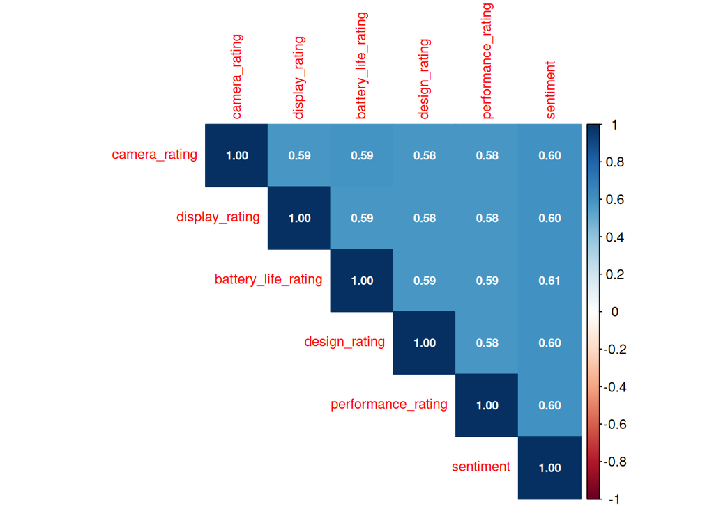

```r
corrplot(cor,
         method = "color",
         type = "upper",
         tl.cex = 0.8,
         addCoef.col = "white",
         number.cex = 0.7)
```

# Podela skupa podataka

Skup podataka ima dovoljnu količinu podataka za analizu – čak 50 hiljada linija, tako da ćemo moći da podelimo skup podataka na trening, validacioni i testni skup bez većih poteškoća.

Uzećemo 60% podataka za trening skup, dok ćemo po 20% uzeti za validacioni i testni skup.

```r
set.seed(123)

index_train = sample(1: nrow(reviews_important_vars), size = 0.6 * nrow(reviews_important_vars))

train = reviews_important_vars[index_train, ]
```

```r
remaining = reviews_important_vars[-index_train, ]
index_test = sample(1:nrow(remaining), size = 0.5 * nrow(remaining))

validation = remaining[index_test, ]
test = remaining[-index_test, ]
```

Proverimo dimenzije sva tri skupa podataka kako bismo potvrdili da je skup podeljen adekvatno.

```r
dim(train)
```

```
## [1] 29898     7
```

```r
dim(test)
```

```
## [1] 9966    7
```

```r
dim(validation)
```

```
## [1] 9966    7
```

Proverimo strukturu trening skupa.

```r
str(train)
```

```
## 'data.frame':    29898 obs. of  7 variables:
##  $ camera_rating      : int  4 2 1 1 1 4 5 1 3 4 ...
##  $ display_rating     : int  2 3 2 1 1 2 4 3 1 3 ...
##  $ battery_life_rating: int  2 3 1 1 1 3 4 4 3 4 ...
##  $ design_rating      : int  3 3 1 1 1 3 4 3 2 4 ...
##  $ performance_rating : int  3 4 1 1 1 4 3 2 1 4 ...
##  $ sentiment          : num  3 3 2 1 1 3 3 2 2 3 ...
##  $ rating             : int  3 3 2 1 1 4 4 3 3 4 ...
```

Ciljna promenljiva je trenutno tipa int, a nama je potrebna klasifikacija u 5 nivoa, zato pretvaramo rating u factor promenljivu.

Takođe ćemo promenljivu sentiment prebaciti u numeričku, neki modeli rade samo sa numeričkim vrednostima, a sentiment ima samo 3 nivoa (Negative, Neutral i Positive).

# Pronalazak modela

Nad prediktorima koje smo odredili primenićemo nekoliko modela kako bismo našli onaj koji najbolje opisuje našu ciljnu promenljivu – rating.

## KNN - K-Nearest Neighbors

Ovo je model koji se koristi za probleme klasifikacije. On predviđa klasu na osnovu klase njenih K najbližih suseda u prostoru karakteristika. Parametar K predstavlja broj suseda koje model uzima u obzir pri odlučivanju o klasi.

Pokrenimo model, i postavimo parametar k na 7.

Kako bismo mogli uspešno da prikažemo matricu konfuzije u ovom modelu, potrebno je najpre ciljnu promenljivu *rating* prebaciti u kategorijsku (faktorsku).

```r
train$rating = factor(train$rating)
validation$rating = factor(validation$rating)
```

```r
library(kknn)
knn_model <- kknn(rating ~ ., train, validation, k = 7, kernel = "triangular")
pred <- fitted(knn_model)
```

Za ovaj model ćemo kreirati konfuzionu matricu.`

```r
confusionMatrix(pred, validation$rating)
```

```
## Confusion Matrix and Statistics
##
##           Reference
## Prediction    1    2    3    4    5
##          1 1064  348    6    0    0
##          2  201 1328  264    0    0
##          3    0  312 1758  371    3
##          4    0    1  402 2124  302
##          5    0    0    0  324 1158
##
## Overall Statistics
##
##                Accuracy : 0.7457
##                  95% CI : (0.7371, 0.7543)
##     No Information Rate : 0.2829
##     P-Value [Acc > NIR] : < 2.2e-16
##
##                   Kappa : 0.6757
##
##  Mcnemar's Test P-Value : NA
##
## Statistics by Class:
##
##                      Class: 1 Class: 2 Class: 3 Class: 4 Class: 5
## Sensitivity            0.8411   0.6677   0.7235   0.7535   0.7915
## Specificity            0.9593   0.9417   0.9090   0.9014   0.9619
## Pos Pred Value         0.7504   0.7407   0.7193   0.7508   0.7814
## Neg Pred Value         0.9765   0.9191   0.9107   0.9026   0.9640
## Prevalence             0.1269   0.1996   0.2438   0.2829   0.1468
## Detection Rate         0.1068   0.1333   0.1764   0.2131   0.1162
## Detection Prevalence   0.1423   0.1799   0.2452   0.2839   0.1487
## Balanced Accuracy      0.9002   0.8047   0.8162   0.8274   0.8767
```

Na prvi pogled vidimo da model ima solidnu preciznost.

Prediction nam govori šta je model predvideo, a Reference šta je stvarna vrednost u nasem skupu.

- Accuracy (0.74) znači da je 74% predikcija tačno, što je solidno.

Kappa (0.6757) - što je takođe solidno.

Sensitivity ( TP/(TP+FN) ) - u koliko procenata model tačno predvidi klasu - vidimo da je ovde raspon od 0.66 do 0.84. Malo bolje prediđa klase 1 i 5 od ostalih (srednjih vrednosti).

Specificity ( TN/(TN+FP) ) - koliko model tacno predvidi da nešto nije ta klasa. Možemo videti da je ovde prilično precizan obzirom da su mu sve vrednosti iznad 0.9.

Možemo pokušati da poboljšamo model povećavanjem parametra K pošto je ta vrednost konfigurabilna.

```r
knn_model_2 <- kknn(rating ~ ., train, validation, k = 125, kernel = "triangular")
pred_2 <- fitted(knn_model)

confusionMatrix(pred_2, validation$rating)
```

```
## Confusion Matrix and Statistics
##
##           Reference
## Prediction    1    2    3    4    5
##          1 1064  348    6    0    0
##          2  201 1328  264    0    0
##          3    0  312 1758  371    3
##          4    0    1  402 2124  302
##          5    0    0    0  324 1158
##
## Overall Statistics
##
##                Accuracy : 0.7457
##                  95% CI : (0.7371, 0.7543)
##     No Information Rate : 0.2829
##     P-Value [Acc > NIR] : < 2.2e-16
##
##                   Kappa : 0.6757
##
##  Mcnemar's Test P-Value : NA
##
## Statistics by Class:
##
##                      Class: 1 Class: 2 Class: 3 Class: 4 Class: 5
## Sensitivity            0.8411   0.6677   0.7235   0.7535   0.7915
## Specificity            0.9593   0.9417   0.9090   0.9014   0.9619
## Pos Pred Value         0.7504   0.7407   0.7193   0.7508   0.7814
## Neg Pred Value         0.9765   0.9191   0.9107   0.9026   0.9640
## Prevalence             0.1269   0.1996   0.2438   0.2829   0.1468
## Detection Rate         0.1068   0.1333   0.1764   0.2131   0.1162
## Detection Prevalence   0.1423   0.1799   0.2452   0.2839   0.1487
## Balanced Accuracy      0.9002   0.8047   0.8162   0.8274   0.8767
```

## Multinomialna Logistička Regresija

MLR je model koji se koristi za probleme klasifikacije sa više od dve klase, odnosno ne koristi se na binarnu klasifikaciju output-a. Predviđa verovatnoću pripadnosti svakoj klasi na osnovu prediktora, a zatim klasu sa najvećom verovatnoćom bira kao predviđenu.

```r
mlr_model = multinom(rating ~ camera_rating + display_rating + battery_life_rating + design_rating + performance_rating + sentiment, data = train)
mlr_predict = predict(mlr_model, newdata = validation)

cm_mlr = confusionMatrix(mlr_predict, validation$rating)
```

```r
cm_mlr
```

```
## Confusion Matrix and Statistics
##
##           Reference
## Prediction    1    2    3    4    5
##          1 1033  268    2    0    0
##          2  232 1455  245    0    0
##          3    0  265 1861  363    2
##          4    0    1  322 2263  382
##          5    0    0    0  193 1079
##
## Overall Statistics
##
##                Accuracy : 0.7717
##                  95% CI : (0.7634, 0.7799)
##     No Information Rate : 0.2829
##     P-Value [Acc > NIR] : < 2.2e-16
##
##                   Kappa : 0.7076
##
##  Mcnemar's Test P-Value : NA
##
## Statistics by Class:
##
##                      Class: 1 Class: 2 Class: 3 Class: 4 Class: 5
## Sensitivity            0.8166   0.7315   0.7658   0.8028   0.7375
## Specificity            0.9690   0.9402   0.9164   0.9014   0.9773
## Pos Pred Value         0.7928   0.7531   0.7471   0.7625   0.8483
## Neg Pred Value         0.9732   0.9335   0.9239   0.9205   0.9558
## Prevalence             0.1269   0.1996   0.2438   0.2829   0.1468
## Detection Rate         0.1037   0.1460   0.1867   0.2271   0.1083
## Detection Prevalence   0.1307   0.1939   0.2499   0.2978   0.1276
## Balanced Accuracy      0.8928   0.8359   0.8411   0.8521   0.8574
```

Iz matrice Prediction vs. Reference odmah vidimo da je model prilično dobar - svakako ima grešaka, ali greške su uglavnom za 1 (ako je prava ocena 4, model eventualno može predvideti da je ocena 3 ili 5).

Model je sasvim zadovoljavajući, ali pokusaćemo da pronađemo još bolji model.

## Naive Bayes

Sličan kao i MLR, predviđa klasu na osnovu verovatnoće svakog prediktora pretpostavljajući da su svi prediktori nezavisni od drugog. Klasa sa najvećom kombinovanom verovatnoćom se bira kao predviđena.

```r
nb_model = naiveBayes(rating ~ ., data = train)

nb_predict = predict(nb_model, newdata = validation)

cm_nb = confusionMatrix(nb_predict, validation$rating)
```

```r
cm_nb
```

```
## Confusion Matrix and Statistics
##
##           Reference
## Prediction    1    2    3    4    5
##          1 1060  342    5    0    0
##          2  205 1351  246    0    0
##          3    0  295 1714  336    0
##          4    0    1  348  565    7
##          5    0    0  117 1918 1456
##
## Overall Statistics
##
##                Accuracy : 0.6167
##                  95% CI : (0.6071, 0.6263)
##     No Information Rate : 0.2829
##     P-Value [Acc > NIR] : < 2.2e-16
##
##                   Kappa : 0.5274
##
##  Mcnemar's Test P-Value : NA
##
## Statistics by Class:
##
##                      Class: 1 Class: 2 Class: 3 Class: 4 Class: 5
## Sensitivity            0.8379   0.6792   0.7053  0.20043   0.9952
## Specificity            0.9601   0.9435   0.9163  0.95019   0.7607
## Pos Pred Value         0.7534   0.7497   0.7309  0.61346   0.4171
## Neg Pred Value         0.9760   0.9219   0.9060  0.75080   0.9989
## Prevalence             0.1269   0.1996   0.2438  0.28286   0.1468
## Detection Rate         0.1064   0.1356   0.1720  0.05669   0.1461
## Detection Prevalence   0.1412   0.1808   0.2353  0.09241   0.3503
## Balanced Accuracy      0.8990   0.8113   0.8108  0.57531   0.8779
```

Probaćemo neke kompleksnije modele, možda nam daju bolje rezultate

## Support Vector Machine - SVM

```r
svm_model = svm(rating ~ ., data = train, kernel = "radial", cost = 1, gamma = 1/ncol(train))

svm_predict = predict(svm_model, validation)

cm_svm = confusionMatrix(svm_predict, validation$rating)
```

Na osnvou metrika, možemo reći da je SVM u rangu sa MLR i da je poprilično dobar model.

```r
cm_svm
```

```
## Confusion Matrix and Statistics
##
##           Reference
## Prediction    1    2    3    4    5
##          1  947  189    1    0    0
##          2  318 1530  239    0    0
##          3    0  269 1866  363    2
##          4    0    1  324 2262  380
##          5    0    0    0  194 1081
##
## Overall Statistics
##
##                Accuracy : 0.7712
##                  95% CI : (0.7628, 0.7794)
##     No Information Rate : 0.2829
##     P-Value [Acc > NIR] : < 2.2e-16
##
##                   Kappa : 0.7065
##
##  Mcnemar's Test P-Value : NA
##
## Statistics by Class:
##
##                      Class: 1 Class: 2 Class: 3 Class: 4 Class: 5
## Sensitivity           0.74862   0.7692   0.7679   0.8024   0.7389
## Specificity           0.97816   0.9302   0.9159   0.9014   0.9772
## Pos Pred Value        0.83289   0.7331   0.7464   0.7624   0.8478
## Neg Pred Value        0.96398   0.9417   0.9245   0.9204   0.9560
## Prevalence            0.12693   0.1996   0.2438   0.2829   0.1468
## Detection Rate        0.09502   0.1535   0.1872   0.2270   0.1085
## Detection Prevalence  0.11409   0.2094   0.2509   0.2977   0.1279
## Balanced Accuracy     0.86339   0.8497   0.8419   0.8519   0.8580
```

## Random Forest

Ovaj model se koristi i za probleme klasifikacije i regresije. On pravi veliki broj stabala odlučivanja pa se konačna odluka donosi izborom jednog.

Random Forest smo već koristili za određivanje najbitnijih prediktora, ovaj put ga koristimo kao model za predikciju.

```r
rf_model = randomForest(rating ~ ., data = train, ntree = 300, mtry = 3, importance = TRUE)

rf_predict = predict(rf_model, newdata = validation)

cm_rf = confusionMatrix(rf_predict, validation$rating)
```

Očekivali smo da će dati bolje rezultate od MLR i SVC modela ali rezultati su slični, čak za nijansu lošiji nego kod ova dva modela.

```r
cm_rf
```

```
## Confusion Matrix and Statistics
##
##           Reference
## Prediction    1    2    3    4    5
##          1  975  217    1    0    0
##          2  290 1462  240    0    0
##          3    0  309 1812  363    2
##          4    0    1  377 2195  313
##          5    0    0    0  261 1148
##
## Overall Statistics
##
##                Accuracy : 0.7618
##                  95% CI : (0.7533, 0.7701)
##     No Information Rate : 0.2829
##     P-Value [Acc > NIR] : < 2.2e-16
##
##                   Kappa : 0.6952
##
##  Mcnemar's Test P-Value : NA
##
## Statistics by Class:
##
##                      Class: 1 Class: 2 Class: 3 Class: 4 Class: 5
## Sensitivity           0.77075   0.7350   0.7457   0.7786   0.7847
## Specificity           0.97495   0.9336   0.9106   0.9033   0.9693
## Pos Pred Value        0.81727   0.7339   0.7289   0.7606   0.8148
## Neg Pred Value        0.96694   0.9339   0.9174   0.9119   0.9632
## Prevalence            0.12693   0.1996   0.2438   0.2829   0.1468
## Detection Rate        0.09783   0.1467   0.1818   0.2202   0.1152
## Detection Prevalence  0.11971   0.1999   0.2494   0.2896   0.1414
## Balanced Accuracy     0.87285   0.8343   0.8281   0.8410   0.8770
```

[Dodato]

## XGBoost

XGBoost je napredna metoda koja kombinuje više odlučujućih stabala da bi stvorila precizan model, uz regularizaciju koja smanjuje overfitting.

Prvo ćemo odraditi pripremu podataka za xgboost Xgboost zahteva numeričke matrice - label za XGB mora biti numeric (klase 0,1,2,3…).

```r
train_matrix <- as.matrix(train[, -7])
train_label <- as.numeric(train$rating) - 1  # XGBoost klase moraju početi od 0

validation_matrix <- as.matrix(validation[, -7])
validation_label <- as.numeric(validation$rating) - 1
```

Kreiranje dmatrix objekata. Dmatrix nam treba isključivo kod xgboost-a, jer je to posebna optimizovana struktura podataka koju XGBoost koristi da bi bio brži, manje trošio memoriju…

```r
dtrain <- xgb.DMatrix(data = train_matrix, label = train_label)
dval <- xgb.DMatrix(data = validation_matrix, label = validation_label)
```

Parametri xgboost modela za multi-class klasifikaciju

```r
num_class <- length(unique(train_label))
```

```r
params <- list(
  booster = "gbtree",
  objective = "multi:softmax",
  num_class = num_class,
  eta = 0.1,
  max_depth = 6,
  subsample = 0.8,
  colsample_bytree = 0.8,
  eval_metric = "mlogloss"
)
```

```r
xgb_model <- xgb.train(
  params = params,
  data = dtrain,
  nrounds = 200,
  evals  = list(train = dtrain, eval = dval),
  early_stopping_rounds = 10,
  print_every_n = 10
)
```

```
## Multiple eval metrics are present. Will use eval_mlogloss for early stopping.
## Will train until eval_mlogloss hasn't improved in 10 rounds.
##
## Stopping. Best iteration:
##
```

```r
xgb_pred <- predict(xgb_model, dval)
```

Pretvaranje nazad u factor za confusion matrix

```r
xgb_pred_factor <- factor(xgb_pred + 1, levels = 1:num_class)
validation_label_factor <- factor(validation_label + 1, levels = 1:num_class)
```

```r
cm_xg_boost = confusionMatrix(xgb_pred_factor, validation_label_factor)

cm_xg_boost
```

```
## Confusion Matrix and Statistics
##
##           Reference
## Prediction    1    2    3    4    5
##          1  981  224    1    0    0
##          2  284 1486  244    0    0
##          3    0  278 1829  344    1
##          4    0    1  356 2250  341
##          5    0    0    0  225 1121
##
## Overall Statistics
##
##                Accuracy : 0.7693
##                  95% CI : (0.7609, 0.7776)
##     No Information Rate : 0.2829
##     P-Value [Acc > NIR] : < 2.2e-16
##
##                   Kappa : 0.7046
##
##  Mcnemar's Test P-Value : NA
##
## Statistics by Class:
##
##                      Class: 1 Class: 2 Class: 3 Class: 4 Class: 5
## Sensitivity           0.77549   0.7471   0.7527   0.7982   0.7662
## Specificity           0.97414   0.9338   0.9173   0.9023   0.9735
## Pos Pred Value        0.81343   0.7378   0.7459   0.7632   0.8328
## Neg Pred Value        0.96758   0.9367   0.9200   0.9189   0.9603
## Prevalence            0.12693   0.1996   0.2438   0.2829   0.1468
## Detection Rate        0.09843   0.1491   0.1835   0.2258   0.1125
## Detection Prevalence  0.12101   0.2021   0.2460   0.2958   0.1351
## Balanced Accuracy     0.87482   0.8405   0.8350   0.8502   0.8699
```

Tačnost na validacionom skupu: Ukupna tačnost (Accuracy): 76% Kappa koeficijent: 0.7

Model podjednako dobro klaifikuje sve klase. XGBoost je dao skoro iste rezultate kao MLR.

## Smanjenje broja prediktora

Pošto su modeli solidni, možemo probati da ih poboljšamo korišćenjem promenljive *avg_rating* koju smo kreirari kao prosečnu ocenu promenljivih koje se završavaju sa *rating*.

Dodatno, gore smo utvrdili da ne postoji jaka multikolinearnost između ovih prediktora, ali pošto je ona umerena možemo pokušati da poboljšamo model na ovaj način.

Kako bismo ostali konzistentni u korišćenju trening, validacionog i testnog skupa tokom upoređivanja svih modela, na već definisane skupove ćemo dodati izračunatu promenljivu *avg_rating*.

```r
train = train %>%
  mutate(avg_rating = rowMeans(across(ends_with("_rating"))))

validation = validation %>%
  mutate(avg_rating = rowMeans(across(ends_with("_rating"))))

test = test %>%
  mutate(avg_rating = rowMeans(across(ends_with("_rating"))))
```

Proverićemo da li je kolona ispravno dodata u skup podataka. Vidimo da postoji promenljiva *avg_rating* i da je numeričkog tipa. Ona predstavlja prosečnu ocenu promenljivih sa sufiksom *rating*.

```r
head(train)
```

|  | camera_rating | display_rating | battery_life_rating | design_rating | performance_rating | sentiment | rating | avg_rating |
| --- | --- | --- | --- | --- | --- | --- | --- | --- |
| 2986 | 4 | 2 | 2 | 3 | 3 | 3 | 3 | 2.8 |
| 29925 | 2 | 3 | 3 | 3 | 4 | 3 | 3 | 3.0 |
| 29710 | 1 | 2 | 1 | 1 | 1 | 2 | 2 | 1.2 |
| 37529 | 1 | 1 | 1 | 1 | 1 | 1 | 1 | 1.0 |
| 2757 | 1 | 1 | 1 | 1 | 1 | 1 | 1 | 1.0 |
| 45404 | 4 | 2 | 3 | 3 | 4 | 3 | 4 | 3.2 |

## Multinomialna regresija sa *avg_rating*

Sada smo redukovali broj prediktora, ali smo ostavili promenljivu *sentiment* kao prediktor. Pokrenimo model MLR kako bismo videli rezultate.

```r
mlr_model_reduced = multinom(rating ~ avg_rating + sentiment, data = train)
```

Ovaj model je podjednako dobar i u ovom slučaju, kada su samo *sentiment* i *avg_rating* uključeni. Ovo treba imati u vidu, zbog kompleksnosti modela. Ovako dobijeni model ima manju kompleksnost, jer ima manji broj prediktora.

```r
mlr_predict = predict(mlr_model_reduced, newdata = validation)

cm_mlr_reduced = confusionMatrix(mlr_predict, validation$rating)

cm_mlr_reduced
```

```
## Confusion Matrix and Statistics
##
##           Reference
## Prediction    1    2    3    4    5
##          1 1033  268    2    0    0
##          2  232 1448  237    0    0
##          3    0  272 1869  363    2
##          4    0    1  322 2263  382
##          5    0    0    0  193 1079
##
## Overall Statistics
##
##                Accuracy : 0.7718
##                  95% CI : (0.7635, 0.78)
##     No Information Rate : 0.2829
##     P-Value [Acc > NIR] : < 2.2e-16
##
##                   Kappa : 0.7077
##
##  Mcnemar's Test P-Value : NA
##
## Statistics by Class:
##
##                      Class: 1 Class: 2 Class: 3 Class: 4 Class: 5
## Sensitivity            0.8166   0.7280   0.7691   0.8028   0.7375
## Specificity            0.9690   0.9412   0.9155   0.9014   0.9773
## Pos Pred Value         0.7928   0.7553   0.7458   0.7625   0.8483
## Neg Pred Value         0.9732   0.9328   0.9248   0.9205   0.9558
## Prevalence             0.1269   0.1996   0.2438   0.2829   0.1468
## Detection Rate         0.1037   0.1453   0.1875   0.2271   0.1083
## Detection Prevalence   0.1307   0.1924   0.2515   0.2978   0.1276
## Balanced Accuracy      0.8928   0.8346   0.8423   0.8521   0.8574
```

## Naive Bayes sa *avg_rating*

```r
nb_model = naiveBayes(rating ~ avg_rating + sentiment, data = train)

nb_predict = predict(nb_model, newdata = validation)

cm_nb_reduced = confusionMatrix(nb_predict, validation$rating)

cm_nb_reduced
```

```
## Confusion Matrix and Statistics
##
##           Reference
## Prediction    1    2    3    4    5
##          1 1033  268    2    0    0
##          2  232 1448  237    0    0
##          3    0  272 1726  336    0
##          4    0    1  319  430    4
##          5    0    0  146 2053 1459
##
## Overall Statistics
##
##                Accuracy : 0.6117
##                  95% CI : (0.602, 0.6213)
##     No Information Rate : 0.2829
##     P-Value [Acc > NIR] : < 2.2e-16
##
##                   Kappa : 0.5221
##
##  Mcnemar's Test P-Value : NA
##
## Statistics by Class:
##
##                      Class: 1 Class: 2 Class: 3 Class: 4 Class: 5
## Sensitivity            0.8166   0.7280   0.7103  0.15254   0.9973
## Specificity            0.9690   0.9412   0.9193  0.95467   0.7414
## Pos Pred Value         0.7928   0.7553   0.7395  0.57029   0.3989
## Neg Pred Value         0.9732   0.9328   0.9078  0.74066   0.9994
## Prevalence             0.1269   0.1996   0.2438  0.28286   0.1468
## Detection Rate         0.1037   0.1453   0.1732  0.04315   0.1464
## Detection Prevalence   0.1307   0.1924   0.2342  0.07566   0.3670
## Balanced Accuracy      0.8928   0.8346   0.8148  0.55360   0.8693
```

## Support Vector Machine - SVM sa *avg_rating*

```r
svm_model_reduced = svm(rating ~ avg_rating + sentiment, data = train, kernel = "radial", cost = 10, gamma = 0.01, scale = TRUE)

svm_predict = predict(svm_model_reduced, validation)

cm_svm_reduced = confusionMatrix(svm_predict, validation$rating)
```

```r
cm_svm_reduced
```

```
## Confusion Matrix and Statistics
##
##           Reference
## Prediction    1    2    3    4    5
##          1  857  135    1    0    0
##          2  408 1581  238    0    0
##          3    0  272 1869  363    2
##          4    0    1  322 2262  382
##          5    0    0    0  194 1079
##
## Overall Statistics
##
##                Accuracy : 0.7674
##                  95% CI : (0.759, 0.7757)
##     No Information Rate : 0.2829
##     P-Value [Acc > NIR] : < 2.2e-16
##
##                   Kappa : 0.7012
##
##  Mcnemar's Test P-Value : NA
##
## Statistics by Class:
##
##                      Class: 1 Class: 2 Class: 3 Class: 4 Class: 5
## Sensitivity           0.67747   0.7949   0.7691   0.8024   0.7375
## Specificity           0.98437   0.9190   0.9155   0.9014   0.9772
## Pos Pred Value        0.86304   0.7099   0.7458   0.7624   0.8476
## Neg Pred Value        0.95453   0.9473   0.9248   0.9204   0.9558
## Prevalence            0.12693   0.1996   0.2438   0.2829   0.1468
## Detection Rate        0.08599   0.1586   0.1875   0.2270   0.1083
## Detection Prevalence  0.09964   0.2235   0.2515   0.2977   0.1277
## Balanced Accuracy     0.83092   0.8569   0.8423   0.8519   0.8574
```

SVM je sasvim dobar model, u rangu sa MLR.

[Dodato]

## Random Forest sa *avg_rating*

Pokušajmo da vidimo kakve rezultate će nam dati Random Forest kada mu smanjimo broj prediktora. Probaćemo i sa manjim brojem stabala da bismo smanjili kompleksnost modela - ako dobijemo slične metrike onda je bolje da imamo manji broj stabala (ntree)

```r
rf_model_reduced = randomForest(rating ~ avg_rating + sentiment, data = train, ntree = 100, mtry = 2, importance = TRUE)

rf_predict = predict(rf_model_reduced, newdata = validation)

cm_rf_reduced = confusionMatrix(rf_predict, validation$rating)

cm_rf_reduced
```

```
## Confusion Matrix and Statistics
##
##           Reference
## Prediction    1    2    3    4    5
##          1 1033  268    2    0    0
##          2  232 1448  237    0    0
##          3    0  272 1869  363    2
##          4    0    1  322 2263  382
##          5    0    0    0  193 1079
##
## Overall Statistics
##
##                Accuracy : 0.7718
##                  95% CI : (0.7635, 0.78)
##     No Information Rate : 0.2829
##     P-Value [Acc > NIR] : < 2.2e-16
##
##                   Kappa : 0.7077
##
##  Mcnemar's Test P-Value : NA
##
## Statistics by Class:
##
##                      Class: 1 Class: 2 Class: 3 Class: 4 Class: 5
## Sensitivity            0.8166   0.7280   0.7691   0.8028   0.7375
## Specificity            0.9690   0.9412   0.9155   0.9014   0.9773
## Pos Pred Value         0.7928   0.7553   0.7458   0.7625   0.8483
## Neg Pred Value         0.9732   0.9328   0.9248   0.9205   0.9558
## Prevalence             0.1269   0.1996   0.2438   0.2829   0.1468
## Detection Rate         0.1037   0.1453   0.1875   0.2271   0.1083
## Detection Prevalence   0.1307   0.1924   0.2515   0.2978   0.1276
## Balanced Accuracy      0.8928   0.8346   0.8423   0.8521   0.8574
```

[Dodato]

## Binarizacija output-a

Ukoliko bismo ciljnu promenljivu podelili u dve kategorije: - Visoka ocena - Niska ocena mogli bismo postići bolje rezultate predikcije.

Na ovaj način bismo mogli dobiti klasifikaciju umesto precizne predikcije, što je u našem skupu podataka sasvim dovoljno.

Najpre ćemo nad trening, test i validacionim skupom podataka odraditi računanje i preslikavanje vrednosti *rating* u novu kolonu. Ukoliko je *rating* ocenjen sa 1 ili 2 tada ćemo model telefona smatrati lošim, dok ćemo veću ocenu smatrati dobrim odnosno visokom ocenom.

Kreirajmo kolonu *high_rating* koja će sadržati ove vrednosti. U ovoj koloni, vrednost 1 predstavlja visoku ocenu (3, 4 ili 5), vrednost 0 nisku ocenu (1 ili 2).

```r
train = train %>%
  mutate(high_rating = ifelse(rating %in% c(3, 4, 5), "True", "False"))

test = test %>%
  mutate(high_rating = ifelse(rating %in% c(3, 4, 5), "True", "False"))

validation = validation %>%
  mutate(high_rating = ifelse(rating %in% c(3, 4, 5), "True", "False"))
```

Pretvorimo promenljivu *high_rating* u faktorsku.

```r
train$high_rating = factor(train$high_rating)
test$high_rating = factor(test$high_rating)
validation$high_rating = factor(validation$high_rating)
```

Pogledajmo strukturu podataka sada. Možemo videti da su vrednosti za *rating* mapirane kao 0 (Loš kvalitet) u koloni *high_rating* dok su više vrednosti mapirane kao 1 (Dobar kvalitet).

```r
str(train)
```

```
## 'data.frame':    29898 obs. of  9 variables:
##  $ camera_rating      : int  4 2 1 1 1 4 5 1 3 4 ...
##  $ display_rating     : int  2 3 2 1 1 2 4 3 1 3 ...
##  $ battery_life_rating: int  2 3 1 1 1 3 4 4 3 4 ...
##  $ design_rating      : int  3 3 1 1 1 3 4 3 2 4 ...
##  $ performance_rating : int  3 4 1 1 1 4 3 2 1 4 ...
##  $ sentiment          : num  3 3 2 1 1 3 3 2 2 3 ...
##  $ rating             : Factor w/ 5 levels "1","2","3","4",..: 3 3 2 1 1 4 4 3 3 4 ...
##  $ avg_rating         : num  2.8 3 1.2 1 1 3.2 4 2.6 2 3.8 ...
##  $ high_rating        : Factor w/ 2 levels "False","True": 2 2 1 1 1 2 2 2 2 2 ...
```

[Dodato]

## Binarna logistička regresija

Ovaj model treba da predvidi verovatnoću pripadnosti jednoj od dve klase. U našem slučaju, 1 je visoka ocena, a 0 niska.

```r
glm_model <- glm(high_rating ~ camera_rating + display_rating + battery_life_rating +
                   design_rating + performance_rating + sentiment,
                 data = train, family = binomial)

glm_pred <- predict(glm_model, newdata = validation, type = "response")
```

```r
glm_class <- factor(ifelse(glm_pred > 0.5, "True", "False"),
                    levels = c("False","True"))
```

```r
str(validation)
```

```
## 'data.frame':    9966 obs. of  9 variables:
##  $ camera_rating      : int  4 1 2 3 4 1 4 1 3 1 ...
##  $ display_rating     : int  3 3 2 3 3 2 4 1 3 3 ...
##  $ battery_life_rating: int  4 1 3 1 4 1 4 1 4 2 ...
##  $ design_rating      : int  3 1 4 1 4 1 5 1 4 4 ...
##  $ performance_rating : int  5 1 4 2 5 2 4 1 5 1 ...
##  $ sentiment          : num  3 1 3 2 2 1 3 1 3 2 ...
##  $ rating             : Factor w/ 5 levels "1","2","3","4",..: 5 1 4 3 4 2 4 1 4 3 ...
##  $ avg_rating         : num  3.8 1.4 3 2 4 1.4 4.2 1 3.8 2.2 ...
##  $ high_rating        : Factor w/ 2 levels "False","True": 2 1 2 2 2 1 2 1 2 2 ...
```

Vidimo da je ovaj model dosta precizan.

```r
cm_binary_output = confusionMatrix(glm_class, validation$high_rating)

cm_binary_output
```

```
## Confusion Matrix and Statistics
##
##           Reference
## Prediction False True
##      False  2988  248
##      True    266 6464
##
##                Accuracy : 0.9484
##                  95% CI : (0.9439, 0.9527)
##     No Information Rate : 0.6735
##     P-Value [Acc > NIR] : <2e-16
##
##                   Kappa : 0.8826
##
##  Mcnemar's Test P-Value : 0.4534
##
##             Sensitivity : 0.9183
##             Specificity : 0.9631
##          Pos Pred Value : 0.9234
##          Neg Pred Value : 0.9605
##              Prevalence : 0.3265
##          Detection Rate : 0.2998
##    Detection Prevalence : 0.3247
##       Balanced Accuracy : 0.9407
##
##        'Positive' Class : False
##
```

Iz matrice konfuzije ćemo izvući vrednosti za *precision* i *recall* i na osnovu njih odraditi f1_score. Parametar *precision* predstavlja koji procenat pozitivno predviđenih slučajeva je zaista pozitivan. Parametar *recall* predstavlja koliki procenat stvarno pozitivnih slučajeva je model uspešno prepoznao. *f1_score* se računa preko ove dve vrednosti i predstavlja harmonijsku sredinu *precision*-a i *recall*-a.

```r
precision = cm_binary_output$byClass["Precision"]
recall = cm_binary_output$byClass["Recall"]

f1_score = 2 * (precision * recall) / (precision + recall)

f1_score
```

```
## Precision
## 0.9208012
```

Predstavimo ROC krivu na grafiku.

```r
roc_value = roc(validation$high_rating, glm_pred)
```

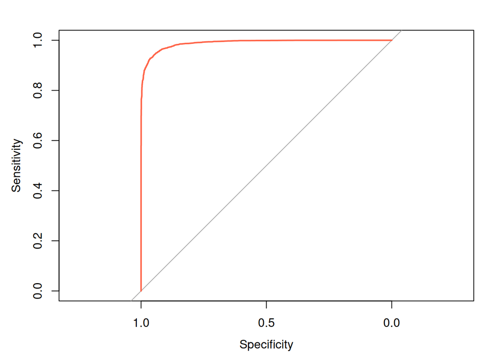

```r
plot(roc_value, col = "tomato")
```

Sa grafika vidimo da je površina ispod ROC krive velika, ali izračunajmo AUC. Vidimo da je vrednost veoma blizu jedinici, što je odlično.

```r
auc_value = auc(roc_value)
auc_value
```

```
## Area under the curve: 0.9893
```

[Dodato]

## Upoređivanje modela kroz metrike

Za svaki od kreiranih modela odradićemo sledeće metrike na osnovu matrice konfuzije.

```r
calc_metrics <- function(cm){
  cm = cm$table
  # cm je numerička matrica, npr. cm$table
  n_classes <- nrow(cm)

  acc <- sum(diag(cm)) / sum(cm)

  precision <- sapply(1:n_classes, function(i) cm[i,i]/sum(cm[,i]))
  recall    <- sapply(1:n_classes, function(i) cm[i,i]/sum(cm[i,]))
  f1        <- 2 * (precision * recall) / (precision + recall)

  macro_precision <- mean(precision, na.rm=TRUE)
  macro_recall    <- mean(recall, na.rm=TRUE)
  macro_f1        <- mean(f1, na.rm=TRUE)

  return(list(
    accuracy = acc,
    macro_precision = macro_precision,
    macro_recall = macro_recall,
    macro_f1 = macro_f1,
    precision = precision,
    recall = recall,
    f1 = f1
  ))
}
```

```r
metrics_mlr <- calc_metrics(cm_mlr)
metrics_nb <- calc_metrics(cm_nb)
metrics_svm <- calc_metrics(cm_svm)
metrics_rf <- calc_metrics(cm_rf)
metrics_xg_boost <- calc_metrics(cm_xg_boost)
metrics_mlr_reduced = calc_metrics(cm_mlr_reduced)
metrics_nb_reduced = calc_metrics(cm_nb_reduced)
metrics_svm_reduced = calc_metrics(cm_svm_reduced)
metrics_rf_reduced = calc_metrics(cm_rf_reduced)
metrics_binary_output = calc_metrics(cm_binary_output)
```

```r
all_metrics <- data.frame(
  model = c(
    "Multinom", "NaiveBayes", "RandomForest", "SVM", "XGBoost",
    "Multinom sa avg_rating", "NaiveBayes sa avg_rating", "RandomForest sa avg_rating", "SVM sa avg_rating",
    "Multinom sa bin. output-om"
  ),
  accuracy = c(
    metrics_mlr$accuracy, metrics_nb$accuracy, metrics_rf$accuracy, metrics_svm$accuracy, metrics_xg_boost$accuracy,
    metrics_mlr_reduced$accuracy, metrics_nb_reduced$accuracy, metrics_rf_reduced$accuracy, metrics_svm_reduced$accuracy,
    metrics_binary_output$accuracy
  ),
  macro_precision = c(
    metrics_mlr$macro_precision, metrics_nb$macro_precision, metrics_rf$macro_precision, metrics_svm$macro_precision, metrics_xg_boost$macro_precision,
    metrics_mlr_reduced$macro_precision, metrics_nb_reduced$macro_precision, metrics_rf_reduced$macro_precision, metrics_svm_reduced$macro_precision,
    metrics_binary_output$macro_precision
  ),
  macro_recall = c(
    metrics_mlr$macro_recall, metrics_nb$macro_recall, metrics_rf$macro_recall, metrics_svm$macro_recall, metrics_xg_boost$macro_recall,
    metrics_mlr_reduced$macro_recall, metrics_nb_reduced$macro_recall, metrics_rf_reduced$macro_recall, metrics_svm_reduced$macro_recall,
    metrics_binary_output$macro_recall
  ),
  macro_f1 = c(
    metrics_mlr$macro_f1, metrics_nb$macro_f1, metrics_rf$macro_f1, metrics_svm$macro_f1, metrics_xg_boost$macro_f1,
    metrics_mlr_reduced$macro_f1, metrics_nb_reduced$macro_f1, metrics_rf_reduced$macro_f1, metrics_svm_reduced$macro_f1,
    metrics_binary_output$macro_f1
  )
)
```

```r
print(all_metrics)
```

```
##                         model  accuracy macro_precision macro_recall  macro_f1
## 1                    Multinom 0.7717239       0.7708521    0.7807435 0.7748308
## 2                  NaiveBayes 0.6166968       0.6836342    0.6529103 0.6228013
## 3                RandomForest 0.7617901       0.7629613    0.7710831 0.7667890
## 4                         SVM 0.7712222       0.7654107    0.7845265 0.7735517
## 5                     XGBoost 0.7693157       0.7679334    0.7786514 0.7728375
## 6      Multinom sa avg_rating 0.7718242       0.7708066    0.7809359 0.7748726
## 7    NaiveBayes sa avg_rating 0.6116797       0.6809390    0.6513559 0.6162093
## 8  RandomForest sa avg_rating 0.7718242       0.7708066    0.7809359 0.7748726
## 9           SVM sa avg_rating 0.7674092       0.7562832    0.7857531 0.7674004
## 10 Multinom sa bin. output-om 0.9484246       0.9406529    0.9419188 0.9412814
```

Na osnovu tabele iznad možemo zaključiti da je multinominalna regresija dala najbolje rezultate za obe varijante (sa *avg_rating* i sa svim ostalim prediktorima). Model koji koristi binarizaciju output-a dao je najbolje rezultate.

# MLFlow

MLFlow je MLOps alat koji omogućava praćenje eksperimenata u mašinskom učenju, uključujući čuvanje parametara, metrika, modela i artifakata vezanih za modele. Njegova svrha je da nam olakša poređenje različitih modela i verzija tokom razvoja. Omogućava nam da imamo sve modele na jednom mestu što nam olakšava izbor najboljeg modela za dalju upotrebu.

## Instalacija MLFlow

MLFlow se može koristiti u lokalnom okruženju (localhost), a postoji mogućnost i da se koristi kao samostalni server ili u cloud infrastrukturi. U našem primeru MLFlow je instaliran lokalno - to nam omogućava jednostavno pokretanje istog i pregled rezultata u korisničkom interfejsu (UI-u) u svom browser-u. Lokalna instalacija je sasvim dovoljna za demonstraciju osnovnih MLFlow funkcionalnosti.

U nastavku je primer instalacije na Linux operativnom sistemu (Ubuntu 24.04):

1. instaliramo **pipx** - alat za instalaciju Python aplikacija *sudo apt install -y pipx*
2. dodajemo **pipx** u path varijablu - ovo nam omogućava da možemo da ga izvršavamo sa bilo koje lokacije na našem računaru *pipx ensurepath*
3. Instalacija **MLFlow-a** *pipx install mlflow*
4. dodajemo mlflow u path - opet da bismo mogli da ga izvršavamo sa bilo koje lokacije na računaru *echo ‘export PATH=“$HOME/.local/bin:$PATH”’ >> ~/.bashrc* *source ~/.bashrc*
5. proveravamo da li smo uspešno instalirali MLFlow *mlflow –version* Ispis treba da bude ovakav (eventualno druga verzija): *mlflow, version 3.8.1*

Nakon što je ovo završeno i validirano je da imamo instaliran MLFlow instaliran na našem racunaru, moramo instalirati i potrebne R pakete - **git2r** i **mlflow** *install.packages(“git2r”)* *install.packages(“mlflow”)*

Potrebno je učitati samo mlflow library u R-u, git2r je samo zavisnost koja nam je potrebna za njegovo korišćenje.

```r
library(mlflow)
```

## Pokretanje MLFlow

Sve što treba da uradimo je da iz terminala pokrenemo sledeću komandu: *mlflow ui* Zatim u browser-u otvorimo http://127.0.0.1:5000 (ili http://localhost:5000) i možemo videti spreman MLFlow UI

U R-u moramo dodati **environment varijable** potrebne za komunikaciju između MLFlow klijenta i servera.

```r
Sys.setenv(
  MLFLOW_BIN = "/home/petrux/.local/bin/mlflow",
  MLFLOW_PYTHON_BIN = "/usr/bin/python3"
)
```

Sledeća komanda nam govori na kojoj lokaciji se trenutno čuvaju logovi poslati sa mlflow klijenta.

```r
mlflow_get_tracking_uri()
```

```
## [1] "file:///home/petrux/Desktop/Uvod u nauku o podacima/data-science-project/data-science-project/mlruns"
```

Da bismo postigli slanje logova na MLFlow UI (umesto pisanja lokalno u direktorijum */mlruns*), moramo dodati **tracking uri**

```r
mlflow_set_tracking_uri("http://127.0.0.1:5000")
```

## Validacija komunikacije između MLFlow klijenta i servera

Odradićemo jedan minimalni test kojim ćemo proveriti da li je sve ispravno podeseno i da li MLFlow klijent iz R-a šalje logove na pravo mesto (MLFlow UI).

```r
mlflow_set_experiment("Test_v2.0")
```

```
## Experiment `Test_v2.0` does not exist. Creating a new experiment.
```

```
## [1] "1"
```

```r
mlflow_start_run()
```

| run_uuid | experiment_id | run_name | user_id | status | start_time | artifact_uri | lifecycle_stage | run_id | end_time | metrics | params | tags |
| --- | --- | --- | --- | --- | --- | --- | --- | --- | --- | --- | --- | --- |
| 7a388b30bbd443628086b2cbaa21add9 | 1 | loud-mouse-253 | petrux | RUNNING | 2026-02-03 21:25:27.540 | mlflow-artifacts:/1/7a388b30bbd443628086b2cbaa21add9/artifacts | active | 7a388b30bbd443628086b2cbaa21add9 | NA | NA | NA |  |

```r
mlflow_log_metric("test", 1)
```

```r
mlflow_end_run()
```

| run_uuid | experiment_id | run_name | user_id | status | start_time | end_time | artifact_uri | lifecycle_stage | run_id | metrics | params | tags |
| --- | --- | --- | --- | --- | --- | --- | --- | --- | --- | --- | --- | --- |
| 7a388b30bbd443628086b2cbaa21add9 | 1 | loud-mouse-253 | petrux | FINISHED | 2026-02-03 21:25:27.540 | 2026-02-03 21:25:27.696 | mlflow-artifacts:/1/7a388b30bbd443628086b2cbaa21add9/artifacts | active | 7a388b30bbd443628086b2cbaa21add9 |  | NA |  |

Nakon ovoga bi trebalo da je testni eksperiment vidljiv u mlflow UI (u Experiments). Takođe u okviru eksperimenta možemo videti “run” koji smo u okviru njega izvršili i metriku koju smo poslali.

[Dodato]

## Poređenje modela

Nakon što smo prosli inicijalno podešavanje, možemo preći na poređenje naših modela koristeći MLFlow.

```r
mlflow_set_experiment("Global_Mobile_Reviews_Models_Exp_2.0")
```

```
## Experiment `Global_Mobile_Reviews_Models_Exp_2.0` does not exist. Creating a new experiment.
```

```
## [1] "2"
```

Nakon sto smo pokrenuli eksperiment, slaćemo jedan po jedan model zajedno sa parametrima i metrikama u MLFlow. Koristićemo modele koje smo već napravili u prethodnim koracima.

## Multinomijalna Logistička Regresija

```r
mlflow_start_run()
```

| run_uuid | experiment_id | run_name | user_id | status | start_time | artifact_uri | lifecycle_stage | run_id | end_time | metrics | params | tags |
| --- | --- | --- | --- | --- | --- | --- | --- | --- | --- | --- | --- | --- |
| a2e5a6f9729d4bdfaa7c7a2928b8c26b | 2 | respected-loon-940 | petrux | RUNNING | 2026-02-03 21:25:27.930 | mlflow-artifacts:/2/a2e5a6f9729d4bdfaa7c7a2928b8c26b/artifacts | active | a2e5a6f9729d4bdfaa7c7a2928b8c26b | NA | NA | NA |  |

Logujemo parametre vezane za model

```r
mlflow_log_param("model_type", "Multinomial_Logistic_Regresion")
mlflow_log_param("predictors_count", 6)
```

Prvo ćemo odraditi predikciju na trening i test skupu koristeci nas MLR model

```r
test$rating = factor(test$rating)

pred_train = predict(mlr_model, newdata = train)
pred_test = predict(mlr_model, newdata = test)
```

Zatim pravimo confision matrix za oba skupa

```r
cm_train = confusionMatrix(pred_train, train$rating)
cm_test = confusionMatrix(pred_test, test$rating)
```

Logovaćemo metrike iz matrice konfuzije u MLFlow

```r
mlflow_log_metric("accuracy_train", cm_train$overall["Accuracy"])
mlflow_log_metric("kappa_train", cm_train$overall["Kappa"])

mlflow_log_metric("accuracy_test", cm_train$overall["Accuracy"])
mlflow_log_metric("kappa_test", cm_train$overall["Kappa"])
```

Takođe možemo logovati i artefakt u vidu .png fajla koji prikazuje matricu konfuzije

```r
plot_cm = function(cm, filename) {
  df = as.data.frame(cm$table)
  colnames(df) = c("Prediction", "Reference", "Freq")

  p = ggplot(df, aes(x = Reference, y = Prediction, fill = Freq)) +
    geom_tile() +
    geom_text(aes(label = Freq), color = "white") +
    scale_fill_gradient(low = "steelblue", high = "darkred") +
    theme_minimal()

  ggsave(filename, p, width = 5, height = 4)
}

plot_cm(cm_test, "cm_mlr_test.png")

mlflow_log_artifact("cm_mlr_test.png")
```

```
## 2026/02/03 21:25:29 INFO mlflow.store.artifact.cli: Logged artifact from local file cm_mlr_test.png to artifact_path=None
```

```
## Root URI: mlflow-artifacts:/2/a2e5a6f9729d4bdfaa7c7a2928b8c26b/artifacts
```

Model cemo takođe logovati kao artefakt da bismo ga kasnije mogli koristiti ukoliko se pokaže kao najbolji

```r
saveRDS(mlr_model, "mlr_model.rds")
mlflow_log_artifact("mlr_model.rds")
```

```
## 2026/02/03 21:25:31 INFO mlflow.store.artifact.cli: Logged artifact from local file mlr_model.rds to artifact_path=None
```

```
## Root URI: mlflow-artifacts:/2/a2e5a6f9729d4bdfaa7c7a2928b8c26b/artifacts
```

```r
mlflow_end_run()
```

| run_uuid | experiment_id | run_name | user_id | status | start_time | end_time | artifact_uri | lifecycle_stage | run_id | metrics | params | tags |
| --- | --- | --- | --- | --- | --- | --- | --- | --- | --- | --- | --- | --- |
| a2e5a6f9729d4bdfaa7c7a2928b8c26b | 2 | respected-loon-940 | petrux | FINISHED | 2026-02-03 21:25:27.930 | 2026-02-03 21:25:31.243 | mlflow-artifacts:/2/a2e5a6f9729d4bdfaa7c7a2928b8c26b/artifacts | active | a2e5a6f9729d4bdfaa7c7a2928b8c26b |  |  |  |

## Multinomijalna Logistička Regresija sa redukovanim brojem prediktora

Koristićemo i model multinomijale logističke regresije sa *avg_rating* + *sentiment* u MLFlow. Postupak je isti kao za prethodni model, samo se parametri razlikuju.

```r
mlflow_start_run()
```

| run_uuid | experiment_id | run_name | user_id | status | start_time | artifact_uri | lifecycle_stage | run_id | end_time | metrics | params | tags |
| --- | --- | --- | --- | --- | --- | --- | --- | --- | --- | --- | --- | --- |
| 2f282a01f59d4deabf78f7452a2549cb | 2 | grandiose-auk-561 | petrux | RUNNING | 2026-02-03 21:25:31.368 | mlflow-artifacts:/2/2f282a01f59d4deabf78f7452a2549cb/artifacts | active | 2f282a01f59d4deabf78f7452a2549cb | NA | NA | NA |  |

Logujemo parametre vezane za model

```r
mlflow_log_param("model_type", "Multinomial_Logistic_Regresion")
mlflow_log_param("predictors_count", 2)
```

Prvo ćemo odraditi predikciju na trening i test skupu koristeći naš MLR REDUCED model

```r
pred_train = predict(mlr_model_reduced, newdata = train)
pred_test = predict(mlr_model_reduced, newdata = test)
```

Zatim pravimo confision matrix za oba skupa

```r
cm_train = confusionMatrix(pred_train, train$rating)
cm_test = confusionMatrix(pred_test, test$rating)
```

Logovaćemo metrike iz matrice konfuzije u MLFlow

```r
mlflow_log_metric("accuracy_train", cm_train$overall["Accuracy"])
mlflow_log_metric("kappa_train", cm_train$overall["Kappa"])

mlflow_log_metric("accuracy_test", cm_train$overall["Accuracy"])
mlflow_log_metric("kappa_test", cm_train$overall["Kappa"])
```

Takođe možemo logovati i artefakt u vidu .png fajla koji prikazuje matricu konfuzije

```r
plot_cm(cm_test, "cm_mlr_reduced_test.png")

mlflow_log_artifact("cm_mlr_reduced_test.png")
```

```
## 2026/02/03 21:25:32 INFO mlflow.store.artifact.cli: Logged artifact from local file cm_mlr_reduced_test.png to artifact_path=None
```

```
## Root URI: mlflow-artifacts:/2/2f282a01f59d4deabf78f7452a2549cb/artifacts
```

Model ćemo takodje logovati kao artefakt da bismo ga kasnije mogli koristiti ukoliko se pokaze kao najbolji

```r
saveRDS(mlr_model_reduced, "mlr_model_reduced.rds")
mlflow_log_artifact("mlr_model_reduced.rds")
```

```
## 2026/02/03 21:25:34 INFO mlflow.store.artifact.cli: Logged artifact from local file mlr_model_reduced.rds to artifact_path=None
```

```
## Root URI: mlflow-artifacts:/2/2f282a01f59d4deabf78f7452a2549cb/artifacts
```

```r
mlflow_end_run()
```

| run_uuid | experiment_id | run_name | user_id | status | start_time | end_time | artifact_uri | lifecycle_stage | run_id | metrics | params | tags |
| --- | --- | --- | --- | --- | --- | --- | --- | --- | --- | --- | --- | --- |
| 2f282a01f59d4deabf78f7452a2549cb | 2 | grandiose-auk-561 | petrux | FINISHED | 2026-02-03 21:25:31.368 | 2026-02-03 21:25:34.721 | mlflow-artifacts:/2/2f282a01f59d4deabf78f7452a2549cb/artifacts | active | 2f282a01f59d4deabf78f7452a2549cb |  |  |  |

## Random Forest

```r
mlflow_start_run()
```

| run_uuid | experiment_id | run_name | user_id | status | start_time | artifact_uri | lifecycle_stage | run_id | end_time | metrics | params | tags |
| --- | --- | --- | --- | --- | --- | --- | --- | --- | --- | --- | --- | --- |
| 97938a0035254927a56ccdd3bb2d3e66 | 2 | tasteful-conch-429 | petrux | RUNNING | 2026-02-03 21:25:34.846 | mlflow-artifacts:/2/97938a0035254927a56ccdd3bb2d3e66/artifacts | active | 97938a0035254927a56ccdd3bb2d3e66 | NA | NA | NA |  |

Logujemo parametre vezane za model

```r
mlflow_log_param("model_type", "Random Forest")
mlflow_log_param("predictors_count", 6)
mlflow_log_param("ntree", 300)
mlflow_log_param("mtry", 3)
```

Prvo ćemo odraditi predikciju na trening i test skupu koristeći nas Random Forest model

```r
pred_train = predict(rf_model, newdata = train)
pred_test = predict(rf_model, newdata = test)
```

Zatim pravimo confision matrix za oba skupa

```r
cm_train = confusionMatrix(pred_train, train$rating)
cm_test = confusionMatrix(pred_test, test$rating)
```

Logovaćemo metrike iz matrice konfuzije u MLFlow

```r
mlflow_log_metric("accuracy_train", cm_train$overall["Accuracy"])
mlflow_log_metric("kappa_train", cm_train$overall["Kappa"])

mlflow_log_metric("accuracy_test", cm_train$overall["Accuracy"])
mlflow_log_metric("kappa_test", cm_train$overall["Kappa"])
```

Takođe možemo logovati i artefakt u vidu .png fajla koji prikazuje matricu konfuzije

```r
plot_cm(cm_test, "cm_rf_test.png")

mlflow_log_artifact("cm_rf_test.png")
```

```
## 2026/02/03 21:25:37 INFO mlflow.store.artifact.cli: Logged artifact from local file cm_rf_test.png to artifact_path=None
```

```
## Root URI: mlflow-artifacts:/2/97938a0035254927a56ccdd3bb2d3e66/artifacts
```

Model ćemo takođe logovati kao artefakt da bismo ga kasnije mogli koristiti ukoliko se pokaže kao najbolji

```r
saveRDS(rf_model, "rf_model.rds")
mlflow_log_artifact("rf_model.rds")
```

```
## 2026/02/03 21:25:39 INFO mlflow.store.artifact.cli: Logged artifact from local file rf_model.rds to artifact_path=None
```

```
## Root URI: mlflow-artifacts:/2/97938a0035254927a56ccdd3bb2d3e66/artifacts
```

```r
mlflow_end_run()
```

| run_uuid | experiment_id | run_name | user_id | status | start_time | end_time | artifact_uri | lifecycle_stage | run_id | metrics | params | tags |
| --- | --- | --- | --- | --- | --- | --- | --- | --- | --- | --- | --- | --- |
| 97938a0035254927a56ccdd3bb2d3e66 | 2 | tasteful-conch-429 | petrux | FINISHED | 2026-02-03 21:25:34.846 | 2026-02-03 21:25:39.490 | mlflow-artifacts:/2/97938a0035254927a56ccdd3bb2d3e66/artifacts | active | 97938a0035254927a56ccdd3bb2d3e66 |  |  |  |

## Random Forest sa redukovanim brojem prediktora i ntree = 100

```r
mlflow_start_run()
```

| run_uuid | experiment_id | run_name | user_id | status | start_time | artifact_uri | lifecycle_stage | run_id | end_time | metrics | params | tags |
| --- | --- | --- | --- | --- | --- | --- | --- | --- | --- | --- | --- | --- |
| 4a6c80db566342b0bef6e32bba86d264 | 2 | nervous-cow-21 | petrux | RUNNING | 2026-02-03 21:25:39.615 | mlflow-artifacts:/2/4a6c80db566342b0bef6e32bba86d264/artifacts | active | 4a6c80db566342b0bef6e32bba86d264 | NA | NA | NA |  |

Logujemo parametre vezane za model

```r
mlflow_log_param("model_type", "Random Forest")
mlflow_log_param("predictors_count", 2)
mlflow_log_param("ntree", 100)
mlflow_log_param("mtry", 2)
```

Prvo ćemo odraditi predikciju na trening i test skupu koristeći naš Random Forest model sa smanjenim brojem prediktora

```r
pred_train = predict(rf_model_reduced, newdata = train)
pred_test = predict(rf_model_reduced, newdata = test)
```

Zatim pravimo confusion matrix za oba skupa

```r
cm_train = confusionMatrix(pred_train, train$rating)
cm_test = confusionMatrix(pred_test, test$rating)
```

Logovaćemo metrike iz matrice konfuzije u MLFlow

```r
mlflow_log_metric("accuracy_train", cm_train$overall["Accuracy"])
mlflow_log_metric("kappa_train", cm_train$overall["Kappa"])

mlflow_log_metric("accuracy_test", cm_train$overall["Accuracy"])
mlflow_log_metric("kappa_test", cm_train$overall["Kappa"])
```

Takođe možemo logovati i artefakt u vidu .png fajla koji prikazuje matricu konfuzije

```r
plot_cm(cm_test, "cm_rf_reduced_test.png")

mlflow_log_artifact("cm_rf_reduced_test.png")
```

```
## 2026/02/03 21:25:41 INFO mlflow.store.artifact.cli: Logged artifact from local file cm_rf_reduced_test.png to artifact_path=None
```

```
## Root URI: mlflow-artifacts:/2/4a6c80db566342b0bef6e32bba86d264/artifacts
```

Model ćemo takodje logovati kao artefakt da bismo ga kasnije mogli koristiti ukoliko se pokaže kao najbolji

```r
saveRDS(rf_model_reduced, "rf_model_reduced.rds")
mlflow_log_artifact("rf_model_reduced.rds")
```

```
## 2026/02/03 21:25:42 INFO mlflow.store.artifact.cli: Logged artifact from local file rf_model_reduced.rds to artifact_path=None
```

```
## Root URI: mlflow-artifacts:/2/4a6c80db566342b0bef6e32bba86d264/artifacts
```

```r
mlflow_end_run()
```

| run_uuid | experiment_id | run_name | user_id | status | start_time | end_time | artifact_uri | lifecycle_stage | run_id | metrics | params | tags |
| --- | --- | --- | --- | --- | --- | --- | --- | --- | --- | --- | --- | --- |
| 4a6c80db566342b0bef6e32bba86d264 | 2 | nervous-cow-21 | petrux | FINISHED | 2026-02-03 21:25:39.615 | 2026-02-03 21:25:42.778 | mlflow-artifacts:/2/4a6c80db566342b0bef6e32bba86d264/artifacts | active | 4a6c80db566342b0bef6e32bba86d264 |  |  |  |

## Random Forest sa redukovanim brojem prediktora i ntree = 200

Napravićemo i Random Forest model sa većim brojem stabala. Time povećavamo kompleksnost modela, ali može da se desi da predviđanje bude bolje.

```r
rf_model_reduced_2 = randomForest(rating ~ avg_rating + sentiment, data = train, ntree = 200, mtry = 2, importance = TRUE)
```

```r
mlflow_start_run()
```

| run_uuid | experiment_id | run_name | user_id | status | start_time | artifact_uri | lifecycle_stage | run_id | end_time | metrics | params | tags |
| --- | --- | --- | --- | --- | --- | --- | --- | --- | --- | --- | --- | --- |
| f6d8f0706d114375812477f41ce1f719 | 2 | placid-bass-921 | petrux | RUNNING | 2026-02-03 21:25:45.03 | mlflow-artifacts:/2/f6d8f0706d114375812477f41ce1f719/artifacts | active | f6d8f0706d114375812477f41ce1f719 | NA | NA | NA |  |

Logujemo parametre vezane za model

```r
mlflow_log_param("model_type", "Random Forest")
mlflow_log_param("predictors_count", 2)
mlflow_log_param("ntree", 200)
mlflow_log_param("mtry", 2)
```

Prvo ćemo odraditi predikciju na trening i test skupu koristeći naš Random Forest model sa smanjenim brojem prediktora

```r
pred_train = predict(rf_model_reduced_2, newdata = train)
pred_test = predict(rf_model_reduced_2, newdata = test)
```

Zatim pravimo confusion matrix za oba skupa

```r
cm_train = confusionMatrix(pred_train, train$rating)
cm_test = confusionMatrix(pred_test, test$rating)
```

Logovaćemo metrike iz matrice konfuzije u MLFlow

```r
mlflow_log_metric("accuracy_train", cm_train$overall["Accuracy"])
mlflow_log_metric("kappa_train", cm_train$overall["Kappa"])

mlflow_log_metric("accuracy_test", cm_train$overall["Accuracy"])
mlflow_log_metric("kappa_test", cm_train$overall["Kappa"])
```

Takodje možemo logovati i artefakt u vidu .png fajla koji prikazuje matricu konfuzije

```r
plot_cm(cm_test, "cm_rf_reduced_2_test.png")

mlflow_log_artifact("cm_rf_reduced_2_test.png")
```

```
## 2026/02/03 21:25:46 INFO mlflow.store.artifact.cli: Logged artifact from local file cm_rf_reduced_2_test.png to artifact_path=None
```

```
## Root URI: mlflow-artifacts:/2/f6d8f0706d114375812477f41ce1f719/artifacts
```

Model ćemo takodje logovati kao artefakt da bismo ga kasnije mogli koristiti ukoliko se pokaže kao najbolji

```r
saveRDS(rf_model_reduced_2, "rf_model_reduced_2.rds")
mlflow_log_artifact("rf_model_reduced_2.rds")
```

```
## 2026/02/03 21:25:48 INFO mlflow.store.artifact.cli: Logged artifact from local file rf_model_reduced_2.rds to artifact_path=None
```

```
## Root URI: mlflow-artifacts:/2/f6d8f0706d114375812477f41ce1f719/artifacts
```

```r
mlflow_end_run()
```

| run_uuid | experiment_id | run_name | user_id | status | start_time | end_time | artifact_uri | lifecycle_stage | run_id | metrics | params | tags |
| --- | --- | --- | --- | --- | --- | --- | --- | --- | --- | --- | --- | --- |
| f6d8f0706d114375812477f41ce1f719 | 2 | placid-bass-921 | petrux | FINISHED | 2026-02-03 21:25:45.03 | 2026-02-03 21:25:48.323 | mlflow-artifacts:/2/f6d8f0706d114375812477f41ce1f719/artifacts | active | f6d8f0706d114375812477f41ce1f719 |  |  |  |

## Support Vector Machine (SVM) Model

Prvo ćemo logovati SVM model sa 6 prediktora koji smo ranije napravili.

```r
mlflow_start_run()
```

| run_uuid | experiment_id | run_name | user_id | status | start_time | artifact_uri | lifecycle_stage | run_id | end_time | metrics | params | tags |
| --- | --- | --- | --- | --- | --- | --- | --- | --- | --- | --- | --- | --- |
| 56cf9640ca2a42e693acb7a7e96851ec | 2 | fortunate-finch-950 | petrux | RUNNING | 2026-02-03 21:25:48.448 | mlflow-artifacts:/2/56cf9640ca2a42e693acb7a7e96851ec/artifacts | active | 56cf9640ca2a42e693acb7a7e96851ec | NA | NA | NA |  |

Logujemo parametre vezane za model

```r
mlflow_log_param("model_type", "Support Vector Machine")
mlflow_log_param("predictors_count", 6)
mlflow_log_param("kernel", "radial")
mlflow_log_param("cost", 1)
mlflow_log_param("gama", 1/ncol(train))
```

```r
pred_train = predict(svm_model, newdata = train)
pred_test = predict(svm_model, newdata = test)
```

Zatim pravimo confusion matrix za oba skupa

```r
cm_train = confusionMatrix(pred_train, train$rating)
cm_test = confusionMatrix(pred_test, test$rating)
```

Logovaćemo metrike iz matrice konfuzije u MLFlow

```r
mlflow_log_metric("accuracy_train", cm_train$overall["Accuracy"])
mlflow_log_metric("kappa_train", cm_train$overall["Kappa"])

mlflow_log_metric("accuracy_test", cm_train$overall["Accuracy"])
mlflow_log_metric("kappa_test", cm_train$overall["Kappa"])
```

Takođe možemo logovati i artefakt u vidu .png fajla koji prikazuje matricu konfuzije

```r
plot_cm(cm_test, "cm_svm_test.png")

mlflow_log_artifact("cm_svm_test.png")
```

```
## 2026/02/03 21:25:58 INFO mlflow.store.artifact.cli: Logged artifact from local file cm_svm_test.png to artifact_path=None
```

```
## Root URI: mlflow-artifacts:/2/56cf9640ca2a42e693acb7a7e96851ec/artifacts
```

Model ćemo takodje logovati kao artefakt da bismo ga kasnije mogli koristiti ukoliko se pokaže kao najbolji

```r
saveRDS(svm_model, "svm_model.rds")
mlflow_log_artifact("svm_model.rds")
```

```
## 2026/02/03 21:26:00 INFO mlflow.store.artifact.cli: Logged artifact from local file svm_model.rds to artifact_path=None
```

```
## Root URI: mlflow-artifacts:/2/56cf9640ca2a42e693acb7a7e96851ec/artifacts
```

```r
mlflow_end_run()
```

| run_uuid | experiment_id | run_name | user_id | status | start_time | end_time | artifact_uri | lifecycle_stage | run_id | metrics | params | tags |
| --- | --- | --- | --- | --- | --- | --- | --- | --- | --- | --- | --- | --- |
| 56cf9640ca2a42e693acb7a7e96851ec | 2 | fortunate-finch-950 | petrux | FINISHED | 2026-02-03 21:25:48.448 | 2026-02-03 21:26:00.292 | mlflow-artifacts:/2/56cf9640ca2a42e693acb7a7e96851ec/artifacts | active | 56cf9640ca2a42e693acb7a7e96851ec |  |  |  |

## Support Vector Machine (SVM) Model sa redukovanim brojem prediktora (sa *avg_rating*)

Logovaćemo i SVM model sa 2 prediktora (avg_rating i sentiment)

```r
mlflow_start_run()
```

| run_uuid | experiment_id | run_name | user_id | status | start_time | artifact_uri | lifecycle_stage | run_id | end_time | metrics | params | tags |
| --- | --- | --- | --- | --- | --- | --- | --- | --- | --- | --- | --- | --- |
| 021a4adc234e40828cd404d79540fd29 | 2 | persistent-dog-668 | petrux | RUNNING | 2026-02-03 21:26:00.418 | mlflow-artifacts:/2/021a4adc234e40828cd404d79540fd29/artifacts | active | 021a4adc234e40828cd404d79540fd29 | NA | NA | NA |  |

Logujemo parametre vezane za model

```r
mlflow_log_param("model_type", "Support Vector Machine")
mlflow_log_param("predictors_count", 2)
mlflow_log_param("kernel", "radial")
mlflow_log_param("cost", 10)
mlflow_log_param("gama", 0.01)
```

```r
pred_train = predict(svm_model_reduced, newdata = train)
pred_test = predict(svm_model_reduced, newdata = test)
```

Zatim pravimo confusion matrix za oba skupa

```r
cm_train = confusionMatrix(pred_train, train$rating)
cm_test = confusionMatrix(pred_test, test$rating)
```

Logovaćemo metrike iz matrice konfuzije u MLFlow

```r
mlflow_log_metric("accuracy_train", cm_train$overall["Accuracy"])
mlflow_log_metric("kappa_train", cm_train$overall["Kappa"])

mlflow_log_metric("accuracy_test", cm_train$overall["Accuracy"])
mlflow_log_metric("kappa_test", cm_train$overall["Kappa"])
```

Takođe možemo logovati i artefakt u vidu .png fajla koji prikazuje matricu konfuzije

```r
plot_cm(cm_test, "cm_svm_reduced_test.png")

mlflow_log_artifact("cm_svm_reduced_test.png")
```

```
## 2026/02/03 21:26:08 INFO mlflow.store.artifact.cli: Logged artifact from local file cm_svm_reduced_test.png to artifact_path=None
```

```
## Root URI: mlflow-artifacts:/2/021a4adc234e40828cd404d79540fd29/artifacts
```

Model ćemo takodje logovati kao artefakt da bismo ga kasnije mogli koristiti ukoliko se pokaže kao najbolji

```r
saveRDS(svm_model_reduced, "svm_model_reduced.rds")
mlflow_log_artifact("svm_model_reduced.rds")
```

```
## 2026/02/03 21:26:09 INFO mlflow.store.artifact.cli: Logged artifact from local file svm_model_reduced.rds to artifact_path=None
```

```
## Root URI: mlflow-artifacts:/2/021a4adc234e40828cd404d79540fd29/artifacts
```

```r
mlflow_end_run()
```

| run_uuid | experiment_id | run_name | user_id | status | start_time | end_time | artifact_uri | lifecycle_stage | run_id | metrics | params | tags |
| --- | --- | --- | --- | --- | --- | --- | --- | --- | --- | --- | --- | --- |
| 021a4adc234e40828cd404d79540fd29 | 2 | persistent-dog-668 | petrux | FINISHED | 2026-02-03 21:26:00.418 | 2026-02-03 21:26:10.08 | mlflow-artifacts:/2/021a4adc234e40828cd404d79540fd29/artifacts | active | 021a4adc234e40828cd404d79540fd29 |  |  |  |

## Korišćenje najboljeg modela

Nakon što smo u MLFlow UI-u odabrali koji je najbolji model, možemo ga učitati sa MLFlow servera za dalje korišćenje. Dakle, koristimo .rds artefakt koji je vezan za najbolji model ranije u nasem radu.

```r
best_model = readRDS("mlr_model_reduced.rds")
pred = predict(best_model, newdata = test)

cm_best_model = confusionMatrix(pred, test$rating)

cm_best_model
```

```
## Confusion Matrix and Statistics
##
##           Reference
## Prediction    1    2    3    4    5
##          1 1054  287    2    0    0
##          2  218 1458  275    0    0
##          3    0  233 1936  330    0
##          4    0    1  310 2245  369
##          5    0    0    0  212 1036
##
## Overall Statistics
##
##                Accuracy : 0.7755
##                  95% CI : (0.7672, 0.7837)
##     No Information Rate : 0.2797
##     P-Value [Acc > NIR] : < 2.2e-16
##
##                   Kappa : 0.7125
##
##  Mcnemar's Test P-Value : NA
##
## Statistics by Class:
##
##                      Class: 1 Class: 2 Class: 3 Class: 4 Class: 5
## Sensitivity            0.8286   0.7367   0.7673   0.8055   0.7374
## Specificity            0.9668   0.9383   0.9244   0.9053   0.9752
## Pos Pred Value         0.7848   0.7473   0.7747   0.7675   0.8301
## Neg Pred Value         0.9747   0.9350   0.9214   0.9230   0.9577
## Prevalence             0.1276   0.1986   0.2532   0.2797   0.1410
## Detection Rate         0.1058   0.1463   0.1943   0.2253   0.1040
## Detection Prevalence   0.1348   0.1958   0.2508   0.2935   0.1252
## Balanced Accuracy      0.8977   0.8375   0.8458   0.8554   0.8563
```

Zaključno sa ovim možemo reći da smo iskoristili MLFlow server za bolju organizaciju modela i lakši odabir najboljeg.